# Who is an All-Star?

```python
#Ezekiel Sung ID:219507107
#Hung Truong ID:301035748
#CSC180
#Final Project
#Due:5/3/21
```

Import Libraries and Helper Functions

```python
import numpy as np
import pandas as pd
from sklearn import preprocessing
from collections.abc import Sequence
from sklearn.model_selection import train_test_split
from tensorflow.keras.models import Sequential
from tensorflow.keras.callbacks import EarlyStopping
from tensorflow.keras import optimizers
from tensorflow.keras.callbacks import ModelCheckpoint
from sklearn import metrics
from tensorflow.keras.layers import Dense, Activation, Dropout
from sklearn.metrics import confusion_matrix, classification_report
import matplotlib.pyplot as plt
import sklearn
%matplotlib inline
from IPython.display import display
from sklearn.linear_model import LogisticRegression
import tensorflow as tf
from tensorflow.keras.datasets import mnist
from tensorflow.keras.models import Sequential
from tensorflow.keras.layers import Dense, Dropout, Flatten
from tensorflow.keras.layers import Conv2D, MaxPooling2D

def encode_text_dummy(df, name):
    dummies = pd.get_dummies(df[name])
    for x in dummies.columns:
        dummy_name = "{}-{}".format(name, x)
        df[dummy_name] = dummies[x]
    df.drop(name, axis=1, inplace=True)

# Convert all missing values in the specified column to the median
def missing_median(df, name):
    med = df[name].median()
    df[name] = df[name].fillna(med)

def encode_numeric_range(df, name, normalized_low=-1, normalized_high=1,
                         data_low=None, data_high=None):
    if data_low is None:
        data_low = min(df[name])
        data_high = max(df[name])

    df[name] = ((df[name] - data_low) / (data_high - data_low)) \
               * (normalized_high - normalized_low) + normalized_low

def encode_text_index(df, name):
    le = preprocessing.LabelEncoder()
    df[name] = le.fit_transform(df[name])
    return le.classes_

def to_xy(df, target):
    result = []
    for x in df.columns:
        if x != target:
            result.append(x)
    # find out the type of the target column.
    target_type = df[target].dtypes
    target_type = target_type[0] if isinstance(target_type, Sequence) else target_type
    # Encode to int for classification, float otherwise. TensorFlow likes 32 bits.
    if target_type in (np.int64, np.int32):
        # Classification
        dummies = pd.get_dummies(df[target])
        return df[result].values.astype(np.float32), dummies.values.astype(np.float32)
    else:
        # Regression
        return df[result].values.astype(np.float32), df[target].values.astype(np.float32)


def encode_numeric_zscore(df, name, mean=None, sd=None):
    if mean is None:
        mean = df[name].mean()

    if sd is None:
        sd = df[name].std()

    df[name] = (df[name] - mean) / sd
def plot_confusion_matrix(cm, names, title='Confusion matrix', cmap=plt.cm.Blues):
    plt.imshow(cm, interpolation='nearest', cmap=cmap)
    plt.title(title)
    plt.colorbar()
    tick_marks = np.arange(len(names))
    plt.xticks(tick_marks, names, rotation=45)
    plt.yticks(tick_marks, names)
    plt.tight_layout()
    plt.ylabel('True label')
    plt.xlabel('Predicted label')

def report_coef(names,coef):
    r = pd.DataFrame( { 'coef': coef, 'positive': coef>=0  }, index = names )
    r = r.sort_values(by=['coef'])
    display(r)
    r['coef'].plot(kind='barh', color=r['positive'].map({True: 'b', False: 'r'}))
```

Create a pandas dataframe from our dataset

```python
import sqlite3
import pandas as pd
# Create your connection.
cnx = sqlite3.connect('basketball.sqlite')

df = pd.read_sql_query("SELECT * FROM Player_Attributes", cnx)
```

```python
df.head()
```

|  | ID | FIRST_NAME | LAST_NAME | DISPLAY_FIRST_LAST | DISPLAY_LAST_COMMA_FIRST | DISPLAY_FI_LAST | PLAYER_SLUG | BIRTHDATE | SCHOOL | COUNTRY | ... | NBA_FLAG | GAMES_PLAYED_FLAG | DRAFT_YEAR | DRAFT_ROUND | DRAFT_NUMBER | PTS | AST | REB | ALL_STAR_APPEARANCES | PIE |
| --- | --- | --- | --- | --- | --- | --- | --- | --- | --- | --- | --- | --- | --- | --- | --- | --- | --- | --- | --- | --- | --- |
| 0 | 76001 | Alaa | Abdelnaby | Alaa Abdelnaby | Abdelnaby, Alaa | A. Abdelnaby | alaa-abdelnaby | 1968-06-24T00:00:00 | Duke | USA | ... | Y | Y | 1990 | 1 | 25 | 5.7 | 0.3 | 3.3 | 0.0 | NaN |
| 1 | 76002 | Zaid | Abdul-Aziz | Zaid Abdul-Aziz | Abdul-Aziz, Zaid | Z. Abdul-Aziz | zaid-abdul-aziz | 1946-04-07T00:00:00 | Iowa State | USA | ... | Y | Y | 1968 | 1 | 5 | 9.0 | 1.2 | 8.0 | 0.0 | NaN |
| 2 | 76003 | Kareem | Abdul-Jabbar | Kareem Abdul-Jabbar | Abdul-Jabbar, Kareem | K. Abdul-Jabbar | kareem-abdul-jabbar | 1947-04-16T00:00:00 | UCLA | USA | ... | Y | Y | 1969 | 1 | 1 | 24.6 | 3.6 | 11.2 | 18.0 | NaN |
| 3 | 51 | Mahmoud | Abdul-Rauf | Mahmoud Abdul-Rauf | Abdul-Rauf, Mahmoud | M. Abdul-Rauf | mahmoud-abdul-rauf | 1969-03-09T00:00:00 | Louisiana State | USA | ... | Y | Y | 1990 | 1 | 3 | 14.6 | 3.5 | 1.9 | 0.0 | NaN |
| 4 | 1505 | Tariq | Abdul-Wahad | Tariq Abdul-Wahad | Abdul-Wahad, Tariq | T. Abdul-Wahad | tariq-abdul-wahad | 1974-11-03T00:00:00 | San Jose State | France | ... | Y | Y | 1997 | 1 | 11 | 7.8 | 1.1 | 3.3 | 0.0 | NaN |

5 rows × 37 columns

Categorize the Relevant Attributes as either categorical or numerical

```python
categorical=['POSITION']
numerical=['PTS','AST','REB','HEIGHT','WEIGHT','SEASON_EXP']
```

Create a new dataframe with only the columns that we need

```python
df_final = pd.concat([df['PTS'],df['AST'],df['REB'],df['HEIGHT'],df['WEIGHT']
                     ,df['POSITION'],df['SEASON_EXP'],df['ALL_STAR_APPEARANCES']],axis=1)
```

```python
df_final.head()
```

|  | PTS | AST | REB | HEIGHT | WEIGHT | POSITION | SEASON_EXP | ALL_STAR_APPEARANCES |
| --- | --- | --- | --- | --- | --- | --- | --- | --- |
| 0 | 5.7 | 0.3 | 3.3 | 82.0 | 240.0 | Forward | 4 | 0.0 |
| 1 | 9.0 | 1.2 | 8.0 | 81.0 | 235.0 | Center | 9 | 0.0 |
| 2 | 24.6 | 3.6 | 11.2 | 86.0 | 225.0 | Center | 19 | 18.0 |
| 3 | 14.6 | 3.5 | 1.9 | 73.0 | 162.0 | Guard | 8 | 0.0 |
| 4 | 7.8 | 1.1 | 3.3 | 78.0 | 235.0 | Forward-Guard | 6 | 0.0 |

One Hot Encode the Categorical column, Position.

```python
encode_text_dummy(df_final,'POSITION')
```

Dropped unwanted columns created from one hot encoding

```python
df_final.drop('POSITION-',axis=1,inplace=True)
df_final.head()
```

|  | PTS | AST | REB | HEIGHT | WEIGHT | SEASON_EXP | ALL_STAR_APPEARANCES | POSITION-Center | POSITION-Center-Forward | POSITION-Forward | POSITION-Forward-Center | POSITION-Forward-Guard | POSITION-Guard | POSITION-Guard-Forward |
| --- | --- | --- | --- | --- | --- | --- | --- | --- | --- | --- | --- | --- | --- | --- |
| 0 | 5.7 | 0.3 | 3.3 | 82.0 | 240.0 | 4 | 0.0 | 0 | 0 | 1 | 0 | 0 | 0 | 0 |
| 1 | 9.0 | 1.2 | 8.0 | 81.0 | 235.0 | 9 | 0.0 | 1 | 0 | 0 | 0 | 0 | 0 | 0 |
| 2 | 24.6 | 3.6 | 11.2 | 86.0 | 225.0 | 19 | 18.0 | 1 | 0 | 0 | 0 | 0 | 0 | 0 |
| 3 | 14.6 | 3.5 | 1.9 | 73.0 | 162.0 | 8 | 0.0 | 0 | 0 | 0 | 0 | 0 | 1 | 0 |
| 4 | 7.8 | 1.1 | 3.3 | 78.0 | 235.0 | 6 | 0.0 | 0 | 0 | 0 | 0 | 1 | 0 | 0 |

Handle missing values with median and normalized the numerical columns

```python
for column in df.columns :
    if column in numerical:
        missing_median(df_final,column)
        encode_numeric_range(df_final,column)
```

Create a new Column that specifies whether or not a player is an all star

```python
df_final['IS_ALLSTAR']=np.where(df_final['ALL_STAR_APPEARANCES']>0,1,0)
```

```python
df_final.drop('ALL_STAR_APPEARANCES',axis=1,inplace=True)
df_final.head()
```

|  | PTS | AST | REB | HEIGHT | WEIGHT | SEASON_EXP | POSITION-Center | POSITION-Center-Forward | POSITION-Forward | POSITION-Forward-Center | POSITION-Forward-Guard | POSITION-Guard | POSITION-Guard-Forward | IS_ALLSTAR |
| --- | --- | --- | --- | --- | --- | --- | --- | --- | --- | --- | --- | --- | --- | --- |
| 0 | -0.641509 | -0.946429 | -0.711790 | 0.307692 | -0.057269 | -0.636364 | 0 | 0 | 1 | 0 | 0 | 0 | 0 | 0 |
| 1 | -0.433962 | -0.785714 | -0.301310 | 0.230769 | -0.101322 | -0.181818 | 1 | 0 | 0 | 0 | 0 | 0 | 0 | 0 |
| 2 | 0.547170 | -0.357143 | -0.021834 | 0.615385 | -0.189427 | 0.727273 | 1 | 0 | 0 | 0 | 0 | 0 | 0 | 1 |
| 3 | -0.081761 | -0.375000 | -0.834061 | -0.384615 | -0.744493 | -0.272727 | 0 | 0 | 0 | 0 | 0 | 1 | 0 | 0 |
| 4 | -0.509434 | -0.803571 | -0.711790 | 0.000000 | -0.101322 | -0.454545 | 0 | 0 | 0 | 0 | 1 | 0 | 0 | 0 |

Set up x,y and split the data to train/test

```python
x_df = df_final.drop('IS_ALLSTAR',1)
x=x_df.values
y=df_final['IS_ALLSTAR'].values
```

```python
x_train, x_test, y_train, y_test = train_test_split(x, y, test_size=0.2, random_state=42)
```

```python
print(x_train.shape)
print(y_train.shape)
print(x_test.shape)
print(y_test.shape)
```

```
(3600, 13)
(3600,)
(900, 13)
(900,)
```

### Pre Regularization FNN Model

Pre Regularization FNN Trial 1

```python
checkpointer = ModelCheckpoint(filepath="dnn/best_weights.hdf5", verbose=0, save_best_only=True)
for i in range(2):
    print(i)

    model = Sequential()
    model.add(Dense(5, input_dim=x.shape[1], activation='sigmoid'))
    model.add(Dense(5))
    model.add(Dense(2, activation='softmax'))

    adam = optimizers.Adam(lr=0.01, beta_1=0.9, beta_2=0.999, epsilon=None, decay=0.0, amsgrad=False)
    sgd = optimizers.SGD(lr=.001)
    model.compile(loss='sparse_categorical_crossentropy', optimizer=sgd)

    monitor = EarlyStopping(monitor='val_loss', min_delta=1e-3, patience=5, verbose=1, mode='auto')


    model.fit(x_train,y_train,validation_data=(x_test,y_test), batch_size= 32, callbacks=[monitor,checkpointer],verbose=2,epochs=500)


model.load_weights('dnn/best_weights.hdf5')


pred = model.predict(x_test)
pred = np.argmax(pred,axis=1)
#y_true = np.argmax(y_test,axis=1)

score = metrics.accuracy_score(y_test, pred)
print("Final accuracy: {}".format(score))
```

```
0
Train on 3600 samples, validate on 900 samples
3600/3600 - 2s - loss: 0.2671 - val_loss: 0.2374
3600/3600 - 0s - loss: 0.2653 - val_loss: 0.2362
3600/3600 - 0s - loss: 0.2637 - val_loss: 0.2352
3600/3600 - 0s - loss: 0.2624 - val_loss: 0.2343
3600/3600 - 0s - loss: 0.2613 - val_loss: 0.2336
3600/3600 - 0s - loss: 0.2603 - val_loss: 0.2330
3600/3600 - 0s - loss: 0.2595 - val_loss: 0.2325
3600/3600 - 0s - loss: 0.2587 - val_loss: 0.2321
3600/3600 - 0s - loss: 0.2581 - val_loss: 0.2317
3600/3600 - 0s - loss: 0.2575 - val_loss: 0.2313
3600/3600 - 0s - loss: 0.2570 - val_loss: 0.2310
3600/3600 - 0s - loss: 0.2565 - val_loss: 0.2307
3600/3600 - 0s - loss: 0.2561 - val_loss: 0.2304
3600/3600 - 0s - loss: 0.2557 - val_loss: 0.2301
3600/3600 - 0s - loss: 0.2553 - val_loss: 0.2298
3600/3600 - 0s - loss: 0.2549 - val_loss: 0.2295
3600/3600 - 0s - loss: 0.2545 - val_loss: 0.2292
3600/3600 - 0s - loss: 0.2542 - val_loss: 0.2289
3600/3600 - 0s - loss: 0.2538 - val_loss: 0.2287
3600/3600 - 0s - loss: 0.2535 - val_loss: 0.2284
3600/3600 - 0s - loss: 0.2531 - val_loss: 0.2281
3600/3600 - 0s - loss: 0.2528 - val_loss: 0.2278
3600/3600 - 0s - loss: 0.2524 - val_loss: 0.2275
3600/3600 - 0s - loss: 0.2521 - val_loss: 0.2272
3600/3600 - 0s - loss: 0.2518 - val_loss: 0.2269
3600/3600 - 0s - loss: 0.2514 - val_loss: 0.2266
3600/3600 - 0s - loss: 0.2511 - val_loss: 0.2263
3600/3600 - 0s - loss: 0.2508 - val_loss: 0.2260
3600/3600 - 0s - loss: 0.2504 - val_loss: 0.2257
3600/3600 - 0s - loss: 0.2501 - val_loss: 0.2253
3600/3600 - 0s - loss: 0.2498 - val_loss: 0.2250
3600/3600 - 0s - loss: 0.2494 - val_loss: 0.2247
3600/3600 - 0s - loss: 0.2491 - val_loss: 0.2244
3600/3600 - 0s - loss: 0.2488 - val_loss: 0.2241
3600/3600 - 0s - loss: 0.2484 - val_loss: 0.2238
3600/3600 - 0s - loss: 0.2481 - val_loss: 0.2234
3600/3600 - 0s - loss: 0.2478 - val_loss: 0.2231
3600/3600 - 0s - loss: 0.2474 - val_loss: 0.2228
```

[output cut: 299 more lines]

```
3600/3600 - 0s - loss: 0.2714 - val_loss: 0.2472
3600/3600 - 0s - loss: 0.2711 - val_loss: 0.2467
3600/3600 - 0s - loss: 0.2709 - val_loss: 0.2463
3600/3600 - 0s - loss: 0.2706 - val_loss: 0.2460
3600/3600 - 0s - loss: 0.2704 - val_loss: 0.2456
3600/3600 - 0s - loss: 0.2702 - val_loss: 0.2454
3600/3600 - 0s - loss: 0.2700 - val_loss: 0.2451
3600/3600 - 0s - loss: 0.2699 - val_loss: 0.2449
3600/3600 - 0s - loss: 0.2697 - val_loss: 0.2447
3600/3600 - 0s - loss: 0.2696 - val_loss: 0.2445
3600/3600 - 0s - loss: 0.2694 - val_loss: 0.2443
3600/3600 - 0s - loss: 0.2693 - val_loss: 0.2441
3600/3600 - 0s - loss: 0.2692 - val_loss: 0.2439
Epoch 00031: early stopping
Final accuracy: 0.9444444444444444
```

Pre Regularization FNN Trial 2

```python
checkpointer = ModelCheckpoint(filepath="dnn/best_weights.hdf5", verbose=0, save_best_only=True)
for i in range(2):
    print(i)

    model = Sequential()
    model.add(Dense(5, input_dim=x.shape[1], activation='tanh'))
    model.add(Dense(5))
    model.add(Dense(2, activation='softmax'))

    adam = optimizers.Adam(lr=0.01, beta_1=0.9, beta_2=0.999, epsilon=None, decay=0.0, amsgrad=False)
    sgd = optimizers.SGD(lr=.001)
    model.compile(loss='sparse_categorical_crossentropy', optimizer=sgd)

    monitor = EarlyStopping(monitor='val_loss', min_delta=1e-3, patience=5, verbose=1, mode='auto')


    model.fit(x_train,y_train,validation_data=(x_test,y_test), batch_size= 32, callbacks=[monitor,checkpointer],verbose=2,epochs=500)


model.load_weights('dnn/best_weights.hdf5')


pred = model.predict(x_test)
pred = np.argmax(pred,axis=1)
#y_true = np.argmax(y_test,axis=1)

score = metrics.accuracy_score(y_test, pred)
print("Final accuracy: {}".format(score))
```

```
0
Train on 3600 samples, validate on 900 samples
3600/3600 - 1s - loss: 0.3256 - val_loss: 0.2936
3600/3600 - 0s - loss: 0.3017 - val_loss: 0.2735
3600/3600 - 0s - loss: 0.2874 - val_loss: 0.2605
3600/3600 - 0s - loss: 0.2781 - val_loss: 0.2518
3600/3600 - 0s - loss: 0.2719 - val_loss: 0.2457
3600/3600 - 0s - loss: 0.2675 - val_loss: 0.2411
3600/3600 - 0s - loss: 0.2642 - val_loss: 0.2376
3600/3600 - 0s - loss: 0.2616 - val_loss: 0.2348
3600/3600 - 0s - loss: 0.2595 - val_loss: 0.2325
3600/3600 - 0s - loss: 0.2578 - val_loss: 0.2305
3600/3600 - 0s - loss: 0.2562 - val_loss: 0.2288
3600/3600 - 0s - loss: 0.2549 - val_loss: 0.2273
3600/3600 - 0s - loss: 0.2536 - val_loss: 0.2258
3600/3600 - 0s - loss: 0.2524 - val_loss: 0.2245
3600/3600 - 0s - loss: 0.2512 - val_loss: 0.2233
3600/3600 - 0s - loss: 0.2501 - val_loss: 0.2221
3600/3600 - 0s - loss: 0.2491 - val_loss: 0.2210
3600/3600 - 0s - loss: 0.2480 - val_loss: 0.2199
3600/3600 - 0s - loss: 0.2470 - val_loss: 0.2188
3600/3600 - 0s - loss: 0.2460 - val_loss: 0.2178
3600/3600 - 0s - loss: 0.2450 - val_loss: 0.2168
3600/3600 - 0s - loss: 0.2441 - val_loss: 0.2158
3600/3600 - 0s - loss: 0.2431 - val_loss: 0.2148
3600/3600 - 0s - loss: 0.2421 - val_loss: 0.2139
3600/3600 - 0s - loss: 0.2412 - val_loss: 0.2129
3600/3600 - 0s - loss: 0.2402 - val_loss: 0.2120
3600/3600 - 0s - loss: 0.2393 - val_loss: 0.2111
3600/3600 - 0s - loss: 0.2384 - val_loss: 0.2101
3600/3600 - 0s - loss: 0.2374 - val_loss: 0.2092
3600/3600 - 0s - loss: 0.2365 - val_loss: 0.2083
3600/3600 - 0s - loss: 0.2356 - val_loss: 0.2074
3600/3600 - 0s - loss: 0.2347 - val_loss: 0.2065
3600/3600 - 0s - loss: 0.2338 - val_loss: 0.2056
3600/3600 - 0s - loss: 0.2328 - val_loss: 0.2047
3600/3600 - 0s - loss: 0.2319 - val_loss: 0.2038
3600/3600 - 0s - loss: 0.2310 - val_loss: 0.2029
3600/3600 - 0s - loss: 0.2301 - val_loss: 0.2020
3600/3600 - 0s - loss: 0.2292 - val_loss: 0.2011
```

[output cut: 264 more lines]

```
3600/3600 - 0s - loss: 0.1347 - val_loss: 0.1202
3600/3600 - 0s - loss: 0.1344 - val_loss: 0.1200
3600/3600 - 0s - loss: 0.1341 - val_loss: 0.1198
3600/3600 - 0s - loss: 0.1339 - val_loss: 0.1195
3600/3600 - 0s - loss: 0.1336 - val_loss: 0.1193
3600/3600 - 0s - loss: 0.1334 - val_loss: 0.1191
3600/3600 - 0s - loss: 0.1331 - val_loss: 0.1189
3600/3600 - 0s - loss: 0.1329 - val_loss: 0.1187
3600/3600 - 0s - loss: 0.1327 - val_loss: 0.1185
3600/3600 - 0s - loss: 0.1324 - val_loss: 0.1183
3600/3600 - 0s - loss: 0.1322 - val_loss: 0.1181
3600/3600 - 0s - loss: 0.1320 - val_loss: 0.1179
3600/3600 - 0s - loss: 0.1318 - val_loss: 0.1177
Epoch 00146: early stopping
Final accuracy: 0.9544444444444444
```

Pre Regularization FNN Trial 3

```python
checkpointer = ModelCheckpoint(filepath="dnn/best_weights.hdf5", verbose=0, save_best_only=True)
for i in range(2):
    print(i)

    model = Sequential()
    model.add(Dense(5, input_dim=x.shape[1], activation='tanh'))
    model.add(Dense(5))
    model.add(Dense(2, activation='softmax'))

    adam = optimizers.Adam(lr=0.01, beta_1=0.9, beta_2=0.999, epsilon=None, decay=0.0, amsgrad=False)
    sgd = optimizers.SGD(lr=.001)
    model.compile(loss='sparse_categorical_crossentropy', optimizer=sgd)

    monitor = EarlyStopping(monitor='val_loss', min_delta=1e-3, patience=5, verbose=1, mode='auto')


    model.fit(x_train,y_train,validation_data=(x_test,y_test), batch_size= 32, callbacks=[monitor,checkpointer],verbose=2,epochs=500)


model.load_weights('dnn/best_weights.hdf5')


pred = model.predict(x_test)
pred = np.argmax(pred,axis=1)
#y_true = np.argmax(y_test,axis=1)

score = metrics.accuracy_score(y_test, pred)
print("Final accuracy: {}".format(score))
```

```
0
Train on 3600 samples, validate on 900 samples
3600/3600 - 1s - loss: 0.6987 - val_loss: 0.6202
3600/3600 - 0s - loss: 0.5673 - val_loss: 0.5111
3600/3600 - 0s - loss: 0.4795 - val_loss: 0.4360
3600/3600 - 0s - loss: 0.4184 - val_loss: 0.3827
3600/3600 - 0s - loss: 0.3748 - val_loss: 0.3436
3600/3600 - 0s - loss: 0.3427 - val_loss: 0.3145
3600/3600 - 0s - loss: 0.3188 - val_loss: 0.2925
3600/3600 - 0s - loss: 0.3008 - val_loss: 0.2756
3600/3600 - 0s - loss: 0.2870 - val_loss: 0.2624
3600/3600 - 0s - loss: 0.2764 - val_loss: 0.2520
3600/3600 - 0s - loss: 0.2679 - val_loss: 0.2436
3600/3600 - 0s - loss: 0.2612 - val_loss: 0.2368
3600/3600 - 0s - loss: 0.2558 - val_loss: 0.2313
3600/3600 - 0s - loss: 0.2513 - val_loss: 0.2267
3600/3600 - 0s - loss: 0.2476 - val_loss: 0.2228
3600/3600 - 0s - loss: 0.2445 - val_loss: 0.2194
3600/3600 - 0s - loss: 0.2418 - val_loss: 0.2165
3600/3600 - 0s - loss: 0.2395 - val_loss: 0.2139
3600/3600 - 0s - loss: 0.2374 - val_loss: 0.2116
3600/3600 - 0s - loss: 0.2355 - val_loss: 0.2096
3600/3600 - 0s - loss: 0.2338 - val_loss: 0.2077
3600/3600 - 0s - loss: 0.2322 - val_loss: 0.2059
3600/3600 - 0s - loss: 0.2307 - val_loss: 0.2043
3600/3600 - 0s - loss: 0.2293 - val_loss: 0.2028
3600/3600 - 0s - loss: 0.2280 - val_loss: 0.2013
3600/3600 - 0s - loss: 0.2266 - val_loss: 0.1999
3600/3600 - 0s - loss: 0.2254 - val_loss: 0.1986
3600/3600 - 0s - loss: 0.2241 - val_loss: 0.1973
3600/3600 - 0s - loss: 0.2229 - val_loss: 0.1960
3600/3600 - 0s - loss: 0.2217 - val_loss: 0.1947
3600/3600 - 0s - loss: 0.2205 - val_loss: 0.1935
3600/3600 - 0s - loss: 0.2193 - val_loss: 0.1923
3600/3600 - 0s - loss: 0.2182 - val_loss: 0.1911
3600/3600 - 0s - loss: 0.2170 - val_loss: 0.1899
3600/3600 - 0s - loss: 0.2158 - val_loss: 0.1887
3600/3600 - 0s - loss: 0.2146 - val_loss: 0.1876
3600/3600 - 0s - loss: 0.2135 - val_loss: 0.1864
3600/3600 - 0s - loss: 0.2123 - val_loss: 0.1853
```

[output cut: 215 more lines]

```
3600/3600 - 0s - loss: 0.1415 - val_loss: 0.1222
3600/3600 - 0s - loss: 0.1412 - val_loss: 0.1220
3600/3600 - 0s - loss: 0.1409 - val_loss: 0.1218
3600/3600 - 0s - loss: 0.1407 - val_loss: 0.1215
3600/3600 - 0s - loss: 0.1404 - val_loss: 0.1213
3600/3600 - 0s - loss: 0.1402 - val_loss: 0.1211
3600/3600 - 0s - loss: 0.1400 - val_loss: 0.1209
3600/3600 - 0s - loss: 0.1397 - val_loss: 0.1207
3600/3600 - 0s - loss: 0.1395 - val_loss: 0.1205
3600/3600 - 0s - loss: 0.1393 - val_loss: 0.1203
3600/3600 - 0s - loss: 0.1391 - val_loss: 0.1201
3600/3600 - 0s - loss: 0.1389 - val_loss: 0.1199
3600/3600 - 0s - loss: 0.1386 - val_loss: 0.1198
Epoch 00122: early stopping
Final accuracy: 0.9544444444444444
```

Pre Regularization FNN Trial 4

```python
checkpointer = ModelCheckpoint(filepath="dnn/best_weights.hdf5", verbose=0, save_best_only=True)
for i in range(2):
    print(i)

    model = Sequential()
    model.add(Dense(5, input_dim=x.shape[1], activation='sigmoid'))
    model.add(Dense(5))
    model.add(Dense(2, activation='softmax'))

    adam = optimizers.Adam(lr=0.01, beta_1=0.9, beta_2=0.999, epsilon=None, decay=0.0, amsgrad=False)
    sgd = optimizers.SGD(lr=1e-6)
    model.compile(loss='sparse_categorical_crossentropy', optimizer=adam)

    monitor = EarlyStopping(monitor='val_loss', min_delta=1e-3, patience=5, verbose=1, mode='auto')


    model.fit(x_train,y_train,validation_data=(x_test,y_test), batch_size= 32, callbacks=[monitor,checkpointer],verbose=2,epochs=500)


model.load_weights('dnn/best_weights.hdf5')


pred = model.predict(x_test)
pred = np.argmax(pred,axis=1)
#y_true = np.argmax(y_test,axis=1)

score = metrics.accuracy_score(y_test, pred)
print("Final accuracy: {}".format(score))
```

```
0
Train on 3600 samples, validate on 900 samples
3600/3600 - 1s - loss: 0.3711 - val_loss: 0.2136
3600/3600 - 0s - loss: 0.1869 - val_loss: 0.1197
3600/3600 - 0s - loss: 0.1336 - val_loss: 0.1114
3600/3600 - 0s - loss: 0.1278 - val_loss: 0.1094
3600/3600 - 0s - loss: 0.1248 - val_loss: 0.1085
3600/3600 - 0s - loss: 0.1227 - val_loss: 0.1075
3600/3600 - 0s - loss: 0.1228 - val_loss: 0.1089
3600/3600 - 0s - loss: 0.1207 - val_loss: 0.1072
3600/3600 - 0s - loss: 0.1195 - val_loss: 0.1061
3600/3600 - 0s - loss: 0.1182 - val_loss: 0.1045
3600/3600 - 0s - loss: 0.1174 - val_loss: 0.1055
3600/3600 - 0s - loss: 0.1173 - val_loss: 0.1113
3600/3600 - 0s - loss: 0.1173 - val_loss: 0.1035
3600/3600 - 0s - loss: 0.1129 - val_loss: 0.1109
3600/3600 - 0s - loss: 0.1147 - val_loss: 0.1017
3600/3600 - 0s - loss: 0.1113 - val_loss: 0.1022
3600/3600 - 0s - loss: 0.1115 - val_loss: 0.1047
3600/3600 - 0s - loss: 0.1098 - val_loss: 0.1011
3600/3600 - 0s - loss: 0.1123 - val_loss: 0.0995
3600/3600 - 0s - loss: 0.1084 - val_loss: 0.0964
3600/3600 - 0s - loss: 0.1087 - val_loss: 0.0976
3600/3600 - 0s - loss: 0.1079 - val_loss: 0.0962
3600/3600 - 0s - loss: 0.1085 - val_loss: 0.0979
3600/3600 - 0s - loss: 0.1059 - val_loss: 0.0971
3600/3600 - 0s - loss: 0.1072 - val_loss: 0.0970
Epoch 00025: early stopping
1
Train on 3600 samples, validate on 900 samples
3600/3600 - 0s - loss: 0.2917 - val_loss: 0.2165
3600/3600 - 0s - loss: 0.1825 - val_loss: 0.1194
3600/3600 - 0s - loss: 0.1321 - val_loss: 0.1132
3600/3600 - 0s - loss: 0.1291 - val_loss: 0.1117
3600/3600 - 0s - loss: 0.1268 - val_loss: 0.1116
3600/3600 - 0s - loss: 0.1254 - val_loss: 0.1090
3600/3600 - 0s - loss: 0.1231 - val_loss: 0.1104
3600/3600 - 0s - loss: 0.1228 - val_loss: 0.1103
3600/3600 - 0s - loss: 0.1213 - val_loss: 0.1120
3600/3600 - 0s - loss: 0.1188 - val_loss: 0.1107
3600/3600 - 0s - loss: 0.1189 - val_loss: 0.1095
Epoch 00011: early stopping
Final accuracy: 0.96
```

Pre Regularization FNN Trial 5

```python
checkpointer = ModelCheckpoint(filepath="dnn/best_weights.hdf5", verbose=0, save_best_only=True)
for i in range(2):
    print(i)

    model = Sequential()
    model.add(Dense(5, input_dim=x.shape[1], activation='sigmoid'))
    model.add(Dense(5))
    model.add(Dense(2, activation='softmax'))

    adam = optimizers.Adam(lr=0.0001, beta_1=0.9, beta_2=0.999, epsilon=None, decay=0.0, amsgrad=False)
    sgd = optimizers.SGD(lr=1e-6)
    model.compile(loss='sparse_categorical_crossentropy', optimizer=adam)

    monitor = EarlyStopping(monitor='val_loss', min_delta=1e-3, patience=5, verbose=1, mode='auto')


    model.fit(x_train,y_train,validation_data=(x_test,y_test), batch_size= 32, callbacks=[monitor,checkpointer],verbose=2,epochs=500)


model.load_weights('dnn/best_weights.hdf5')


pred = model.predict(x_test)
pred = np.argmax(pred,axis=1)
#y_true = np.argmax(y_test,axis=1)

score = metrics.accuracy_score(y_test, pred)
print("Final accuracy: {}".format(score))
```

```
0
Train on 3600 samples, validate on 900 samples
3600/3600 - 1s - loss: 1.9233 - val_loss: 1.8396
3600/3600 - 0s - loss: 1.7034 - val_loss: 1.6293
3600/3600 - 0s - loss: 1.5093 - val_loss: 1.4426
3600/3600 - 0s - loss: 1.3367 - val_loss: 1.2757
3600/3600 - 0s - loss: 1.1824 - val_loss: 1.1261
3600/3600 - 0s - loss: 1.0437 - val_loss: 0.9908
3600/3600 - 0s - loss: 0.9186 - val_loss: 0.8689
3600/3600 - 0s - loss: 0.8061 - val_loss: 0.7596
3600/3600 - 0s - loss: 0.7066 - val_loss: 0.6629
3600/3600 - 0s - loss: 0.6204 - val_loss: 0.5804
3600/3600 - 0s - loss: 0.5475 - val_loss: 0.5113
3600/3600 - 0s - loss: 0.4874 - val_loss: 0.4546
3600/3600 - 0s - loss: 0.4389 - val_loss: 0.4088
3600/3600 - 0s - loss: 0.4005 - val_loss: 0.3730
3600/3600 - 0s - loss: 0.3705 - val_loss: 0.3446
3600/3600 - 0s - loss: 0.3472 - val_loss: 0.3225
3600/3600 - 0s - loss: 0.3293 - val_loss: 0.3051
3600/3600 - 0s - loss: 0.3154 - val_loss: 0.2918
3600/3600 - 0s - loss: 0.3050 - val_loss: 0.2815
3600/3600 - 0s - loss: 0.2969 - val_loss: 0.2733
3600/3600 - 0s - loss: 0.2907 - val_loss: 0.2670
3600/3600 - 0s - loss: 0.2860 - val_loss: 0.2620
3600/3600 - 0s - loss: 0.2823 - val_loss: 0.2580
3600/3600 - 0s - loss: 0.2795 - val_loss: 0.2549
3600/3600 - 0s - loss: 0.2773 - val_loss: 0.2523
3600/3600 - 0s - loss: 0.2754 - val_loss: 0.2502
3600/3600 - 0s - loss: 0.2739 - val_loss: 0.2484
3600/3600 - 0s - loss: 0.2727 - val_loss: 0.2468
3600/3600 - 0s - loss: 0.2715 - val_loss: 0.2454
3600/3600 - 0s - loss: 0.2705 - val_loss: 0.2443
3600/3600 - 0s - loss: 0.2695 - val_loss: 0.2431
3600/3600 - 0s - loss: 0.2685 - val_loss: 0.2420
3600/3600 - 0s - loss: 0.2676 - val_loss: 0.2409
3600/3600 - 0s - loss: 0.2666 - val_loss: 0.2399
3600/3600 - 0s - loss: 0.2657 - val_loss: 0.2389
3600/3600 - 0s - loss: 0.2647 - val_loss: 0.2379
3600/3600 - 0s - loss: 0.2637 - val_loss: 0.2369
3600/3600 - 0s - loss: 0.2627 - val_loss: 0.2358
```

[output cut: 241 more lines]

```
3600/3600 - 0s - loss: 0.1369 - val_loss: 0.1181
3600/3600 - 0s - loss: 0.1365 - val_loss: 0.1178
3600/3600 - 0s - loss: 0.1362 - val_loss: 0.1176
3600/3600 - 0s - loss: 0.1359 - val_loss: 0.1173
3600/3600 - 0s - loss: 0.1356 - val_loss: 0.1171
3600/3600 - 0s - loss: 0.1353 - val_loss: 0.1168
3600/3600 - 0s - loss: 0.1350 - val_loss: 0.1166
3600/3600 - 0s - loss: 0.1347 - val_loss: 0.1164
3600/3600 - 0s - loss: 0.1346 - val_loss: 0.1162
3600/3600 - 0s - loss: 0.1343 - val_loss: 0.1160
3600/3600 - 0s - loss: 0.1340 - val_loss: 0.1158
3600/3600 - 0s - loss: 0.1338 - val_loss: 0.1156
3600/3600 - 0s - loss: 0.1336 - val_loss: 0.1155
Epoch 00153: early stopping
Final accuracy: 0.9566666666666667
```

Pre Regularization FNN Trial 6

```python
checkpointer = ModelCheckpoint(filepath="dnn/best_weights.hdf5", verbose=0, save_best_only=True)
for i in range(2):
    print(i)

    model = Sequential()
    model.add(Dense(5, input_dim=x.shape[1], activation='tanh'))
    model.add(Dense(5))
    model.add(Dense(2, activation='softmax'))

    adam = optimizers.Adam(lr=0.01, beta_1=0.9, beta_2=0.999, epsilon=None, decay=0.0, amsgrad=False)
    sgd = optimizers.SGD(lr=1e-6)
    model.compile(loss='sparse_categorical_crossentropy', optimizer=adam)

    monitor = EarlyStopping(monitor='val_loss', min_delta=1e-3, patience=5, verbose=1, mode='auto')


    model.fit(x_train,y_train,validation_data=(x_test,y_test), batch_size= 32, callbacks=[monitor,checkpointer],verbose=2,epochs=500)


model.load_weights('dnn/best_weights.hdf5')


pred = model.predict(x_test)
pred = np.argmax(pred,axis=1)
#y_true = np.argmax(y_test,axis=1)

score = metrics.accuracy_score(y_test, pred)
print("Final accuracy: {}".format(score))
```

```
0
Train on 3600 samples, validate on 900 samples
3600/3600 - 3s - loss: 0.1764 - val_loss: 0.1141
3600/3600 - 0s - loss: 0.1350 - val_loss: 0.1166
3600/3600 - 0s - loss: 0.1299 - val_loss: 0.1110
3600/3600 - 0s - loss: 0.1252 - val_loss: 0.1136
3600/3600 - 0s - loss: 0.1246 - val_loss: 0.1171
3600/3600 - 0s - loss: 0.1264 - val_loss: 0.1094
3600/3600 - 0s - loss: 0.1213 - val_loss: 0.1098
3600/3600 - 0s - loss: 0.1217 - val_loss: 0.1095
3600/3600 - 0s - loss: 0.1220 - val_loss: 0.1107
3600/3600 - 0s - loss: 0.1204 - val_loss: 0.1064
3600/3600 - 0s - loss: 0.1174 - val_loss: 0.1128
3600/3600 - 0s - loss: 0.1173 - val_loss: 0.1045
3600/3600 - 0s - loss: 0.1133 - val_loss: 0.1078
3600/3600 - 0s - loss: 0.1136 - val_loss: 0.1077
3600/3600 - 0s - loss: 0.1151 - val_loss: 0.1034
3600/3600 - 0s - loss: 0.1144 - val_loss: 0.1026
3600/3600 - 0s - loss: 0.1128 - val_loss: 0.1017
3600/3600 - 0s - loss: 0.1109 - val_loss: 0.1136
3600/3600 - 0s - loss: 0.1152 - val_loss: 0.1014
3600/3600 - 0s - loss: 0.1102 - val_loss: 0.1008
3600/3600 - 0s - loss: 0.1093 - val_loss: 0.1095
3600/3600 - 0s - loss: 0.1096 - val_loss: 0.0987
3600/3600 - 0s - loss: 0.1100 - val_loss: 0.1005
3600/3600 - 0s - loss: 0.1099 - val_loss: 0.0958
3600/3600 - 0s - loss: 0.1074 - val_loss: 0.1034
3600/3600 - 0s - loss: 0.1084 - val_loss: 0.0937
3600/3600 - 0s - loss: 0.1068 - val_loss: 0.0972
3600/3600 - 0s - loss: 0.1076 - val_loss: 0.0934
3600/3600 - 0s - loss: 0.1060 - val_loss: 0.0945
3600/3600 - 0s - loss: 0.1051 - val_loss: 0.0941
3600/3600 - 0s - loss: 0.1047 - val_loss: 0.0933
Epoch 00031: early stopping
1
Train on 3600 samples, validate on 900 samples
3600/3600 - 2s - loss: 0.2541 - val_loss: 0.1162
3600/3600 - 0s - loss: 0.1346 - val_loss: 0.1118
3600/3600 - 0s - loss: 0.1278 - val_loss: 0.1281
3600/3600 - 0s - loss: 0.1279 - val_loss: 0.1126
```

[output cut: 9 more lines]

```
3600/3600 - 0s - loss: 0.1141 - val_loss: 0.1016
3600/3600 - 0s - loss: 0.1133 - val_loss: 0.0981
3600/3600 - 0s - loss: 0.1125 - val_loss: 0.1011
3600/3600 - 0s - loss: 0.1127 - val_loss: 0.0986
3600/3600 - 0s - loss: 0.1108 - val_loss: 0.0978
3600/3600 - 0s - loss: 0.1124 - val_loss: 0.0955
3600/3600 - 0s - loss: 0.1100 - val_loss: 0.0950
3600/3600 - 0s - loss: 0.1114 - val_loss: 0.0941
3600/3600 - 0s - loss: 0.1092 - val_loss: 0.0945
3600/3600 - 0s - loss: 0.1097 - val_loss: 0.0938
3600/3600 - 0s - loss: 0.1078 - val_loss: 0.0952
3600/3600 - 0s - loss: 0.1080 - val_loss: 0.0985
3600/3600 - 0s - loss: 0.1075 - val_loss: 0.0954
Epoch 00026: early stopping
Final accuracy: 0.9611111111111111
```

### Best FNN Model Pre Regularization

Pre Regularization FNN Trial 6

```python
model.summary()
```

```
Model: "sequential_49"
_________________________________________________________________
Layer (type)                 Output Shape              Param #
=================================================================
dense_122 (Dense)            (None, 5)                 70
_________________________________________________________________
dense_123 (Dense)            (None, 5)                 30
_________________________________________________________________
dense_124 (Dense)            (None, 2)                 12
=================================================================
Total params: 112
Trainable params: 112
Non-trainable params: 0
_________________________________________________________________
```

```
[[815  19]
 [ 16  50]]
Ploting confusion matrix
```

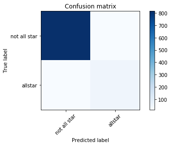

```
              precision    recall  f1-score   support

           0       0.98      0.98      0.98       834
           1       0.72      0.76      0.74        66

    accuracy                           0.96       900
   macro avg       0.85      0.87      0.86       900
weighted avg       0.96      0.96      0.96       900

Final accuracy: 0.9611111111111111
```

```python
cm = confusion_matrix(y_test, pred)
print(cm)

print('Ploting confusion matrix')
plt.figure()
plot_confusion_matrix(cm, ('not all star','allstar'))
plt.show()


print(classification_report(y_test, pred))
print("Final accuracy: {}".format(score))
```

### Pre Regularization CNN Model

Reshape the x data

```python
x.shape
```

```
(4500, 13)
```

```python
xx= x.reshape((4500,1,13,1))
```

Pre Regularization CNN Model Trial 1

```python
cnn = Sequential()
cnn.add(Conv2D(256, kernel_size=(1, 2), strides=(1, 1),
                 activation='sigmoid',
                 input_shape=(1, 13, 1)))


cnn.add(MaxPooling2D(pool_size=(1,2)))

cnn.add(Conv2D(256, kernel_size=(1, 2), strides=(1, 1),
                 activation='tanh'))
cnn.add(MaxPooling2D(pool_size=(1,2)))


cnn.add(Flatten())
cnn.add(Dense(1024, activation="sigmoid"))
cnn.add(Dropout(0.5))
cnn.add(Dense(2, activation="softmax"))

# define optimizer and objective, compile cnn

cnn.compile(loss="sparse_categorical_crossentropy", optimizer="sgd")

x_train, x_test, y_train, y_test = train_test_split(xx, y, test_size=0.2, random_state=42)

import time

start_time = time.time()
checkpointer = ModelCheckpoint(filepath="dnn/best_weights.hdf5", verbose=0, save_best_only=True)
for i in range(5):
    print(i)

    monitor = EarlyStopping(monitor='val_loss', min_delta=1e-3, patience=5, verbose=1, mode='auto')
    cnn.fit(x_train[0:15000], y_train[0:15000],
              batch_size=64,
              epochs=10,
              verbose=2,
               callbacks=[monitor,checkpointer],
              validation_data=(x_test[0:300], y_test[0:300]))

pred2 = cnn.predict(x_test)
pred2 = np.argmax(pred2,axis=1)
#y_true = np.argmax(y_test,axis=1)

score = metrics.accuracy_score(y_test, pred2)
print("Final accuracy: {}".format(score))
```

```
0
Train on 3600 samples, validate on 300 samples
3600/3600 - 2s - loss: 0.3564 - val_loss: 0.2788
3600/3600 - 1s - loss: 0.3195 - val_loss: 0.2646
3600/3600 - 1s - loss: 0.3228 - val_loss: 0.2643
3600/3600 - 1s - loss: 0.3188 - val_loss: 0.2628
3600/3600 - 1s - loss: 0.3181 - val_loss: 0.2662
3600/3600 - 1s - loss: 0.3186 - val_loss: 0.2654
3600/3600 - 1s - loss: 0.3102 - val_loss: 0.2722
3600/3600 - 1s - loss: 0.3104 - val_loss: 0.2626
3600/3600 - 1s - loss: 0.3144 - val_loss: 0.2973
Epoch 00009: early stopping
1
Train on 3600 samples, validate on 300 samples
3600/3600 - 1s - loss: 0.3181 - val_loss: 0.2630
3600/3600 - 1s - loss: 0.3140 - val_loss: 0.2680
3600/3600 - 1s - loss: 0.3203 - val_loss: 0.2635
3600/3600 - 1s - loss: 0.3111 - val_loss: 0.2755
3600/3600 - 1s - loss: 0.3134 - val_loss: 0.2649
3600/3600 - 1s - loss: 0.3131 - val_loss: 0.2644
Epoch 00006: early stopping
2
Train on 3600 samples, validate on 300 samples
3600/3600 - 1s - loss: 0.3099 - val_loss: 0.2652
3600/3600 - 1s - loss: 0.3078 - val_loss: 0.2634
3600/3600 - 1s - loss: 0.3051 - val_loss: 0.2783
3600/3600 - 1s - loss: 0.3091 - val_loss: 0.2635
3600/3600 - 1s - loss: 0.3051 - val_loss: 0.3082
3600/3600 - 1s - loss: 0.3047 - val_loss: 0.2744
3600/3600 - 1s - loss: 0.3042 - val_loss: 0.2650
Epoch 00007: early stopping
3
Train on 3600 samples, validate on 300 samples
3600/3600 - 1s - loss: 0.3090 - val_loss: 0.2634
3600/3600 - 1s - loss: 0.3034 - val_loss: 0.2641
3600/3600 - 1s - loss: 0.3100 - val_loss: 0.2622
3600/3600 - 1s - loss: 0.3030 - val_loss: 0.2631
3600/3600 - 1s - loss: 0.3026 - val_loss: 0.2623
3600/3600 - 1s - loss: 0.3010 - val_loss: 0.2638
3600/3600 - 1s - loss: 0.3019 - val_loss: 0.2625
3600/3600 - 1s - loss: 0.2998 - val_loss: 0.2782
Epoch 00008: early stopping
4
Train on 3600 samples, validate on 300 samples
3600/3600 - 1s - loss: 0.3010 - val_loss: 0.2768
3600/3600 - 1s - loss: 0.3022 - val_loss: 0.2655
3600/3600 - 1s - loss: 0.2924 - val_loss: 0.2720
3600/3600 - 1s - loss: 0.2998 - val_loss: 0.2624
3600/3600 - 1s - loss: 0.2998 - val_loss: 0.2695
3600/3600 - 1s - loss: 0.3019 - val_loss: 0.2634
3600/3600 - 1s - loss: 0.2983 - val_loss: 0.2619
3600/3600 - 1s - loss: 0.3019 - val_loss: 0.2639
3600/3600 - 1s - loss: 0.2983 - val_loss: 0.2668
Epoch 00009: early stopping
Final accuracy: 0.9266666666666666
```

Pre Regularization CNN Model Trial 2

```python
cnn = Sequential()
cnn.add(Conv2D(256, kernel_size=(1, 2), strides=(1, 1),
                 activation='relu',
                 input_shape=(1, 13, 1)))


cnn.add(MaxPooling2D(pool_size=(1,2)))

cnn.add(Conv2D(256, kernel_size=(1, 2), strides=(1, 1),
                 activation='relu'))
cnn.add(MaxPooling2D(pool_size=(1,2)))


cnn.add(Flatten())
cnn.add(Dense(1024, activation="sigmoid"))
cnn.add(Dropout(0.5))
cnn.add(Dense(2, activation="softmax"))

# define optimizer and objective, compile cnn

cnn.compile(loss="sparse_categorical_crossentropy", optimizer="adam")

x_train, x_test, y_train, y_test = train_test_split(xx, y, test_size=0.2, random_state=42)

import time

start_time = time.time()
checkpointer = ModelCheckpoint(filepath="dnn/best_weights.hdf5", verbose=0, save_best_only=True)
for i in range(5):
    print(i)

    monitor = EarlyStopping(monitor='val_loss', min_delta=1e-3, patience=5, verbose=1, mode='auto')
    cnn.fit(x_train[0:2000], y_train[0:2000],
              batch_size=64,
              epochs=10,
              verbose=2,
               callbacks=[monitor,checkpointer],
              validation_data=(x_test[0:300], y_test[0:300]))

pred2 = cnn.predict(x_test)
pred2 = np.argmax(pred2,axis=1)
#y_true = np.argmax(y_test,axis=1)

score = metrics.accuracy_score(y_test, pred2)
print("Final accuracy: {}".format(score))
```

```
0
Train on 2000 samples, validate on 300 samples
2000/2000 - 2s - loss: 0.3931 - val_loss: 0.2364
2000/2000 - 0s - loss: 0.2318 - val_loss: 0.1376
2000/2000 - 0s - loss: 0.1660 - val_loss: 0.0956
2000/2000 - 0s - loss: 0.1467 - val_loss: 0.0820
2000/2000 - 0s - loss: 0.1332 - val_loss: 0.0832
2000/2000 - 0s - loss: 0.1432 - val_loss: 0.0774
2000/2000 - 0s - loss: 0.1302 - val_loss: 0.0798
2000/2000 - 0s - loss: 0.1346 - val_loss: 0.0774
2000/2000 - 0s - loss: 0.1249 - val_loss: 0.0849
2000/2000 - 0s - loss: 0.1273 - val_loss: 0.0789
1
Train on 2000 samples, validate on 300 samples
2000/2000 - 0s - loss: 0.1268 - val_loss: 0.0738
2000/2000 - 0s - loss: 0.1255 - val_loss: 0.0767
2000/2000 - 0s - loss: 0.1183 - val_loss: 0.0756
2000/2000 - 0s - loss: 0.1318 - val_loss: 0.0735
2000/2000 - 0s - loss: 0.1209 - val_loss: 0.0751
2000/2000 - 0s - loss: 0.1176 - val_loss: 0.0732
Epoch 00006: early stopping
2
Train on 2000 samples, validate on 300 samples
2000/2000 - 0s - loss: 0.1207 - val_loss: 0.0714
2000/2000 - 0s - loss: 0.1133 - val_loss: 0.0673
2000/2000 - 0s - loss: 0.1192 - val_loss: 0.0884
2000/2000 - 0s - loss: 0.1248 - val_loss: 0.0695
2000/2000 - 0s - loss: 0.1076 - val_loss: 0.0683
2000/2000 - 0s - loss: 0.1137 - val_loss: 0.0733
2000/2000 - 0s - loss: 0.1087 - val_loss: 0.0731
Epoch 00007: early stopping
3
Train on 2000 samples, validate on 300 samples
2000/2000 - 0s - loss: 0.1169 - val_loss: 0.0695
2000/2000 - 0s - loss: 0.1105 - val_loss: 0.0775
2000/2000 - 0s - loss: 0.1139 - val_loss: 0.0732
2000/2000 - 0s - loss: 0.1139 - val_loss: 0.0724
2000/2000 - 0s - loss: 0.1131 - val_loss: 0.0695
2000/2000 - 0s - loss: 0.1253 - val_loss: 0.0699
Epoch 00006: early stopping
4
Train on 2000 samples, validate on 300 samples
2000/2000 - 0s - loss: 0.1042 - val_loss: 0.0740
2000/2000 - 0s - loss: 0.1193 - val_loss: 0.0755
2000/2000 - 0s - loss: 0.1131 - val_loss: 0.0700
2000/2000 - 0s - loss: 0.1092 - val_loss: 0.0728
2000/2000 - 0s - loss: 0.1028 - val_loss: 0.0688
2000/2000 - 0s - loss: 0.1079 - val_loss: 0.0709
2000/2000 - 0s - loss: 0.1060 - val_loss: 0.0807
2000/2000 - 0s - loss: 0.1127 - val_loss: 0.0681
2000/2000 - 0s - loss: 0.1122 - val_loss: 0.0707
2000/2000 - 0s - loss: 0.1075 - val_loss: 0.0695
Epoch 00010: early stopping
Final accuracy: 0.9622222222222222
```

Pre Regularization CNN Model Trial 3

```python
cnn = Sequential()
cnn.add(Conv2D(256, kernel_size=(1, 2), strides=(1, 1),
                 activation='relu',
                 input_shape=(1, 13, 1)))


cnn.add(MaxPooling2D(pool_size=(1,2)))

cnn.add(Conv2D(256, kernel_size=(1, 2), strides=(1, 1),
                 activation='relu'))
cnn.add(MaxPooling2D(pool_size=(1,2)))


cnn.add(Flatten())
cnn.add(Dense(1024, activation="sigmoid"))
cnn.add(Dropout(0.5))
cnn.add(Dense(2, activation="softmax"))

# define optimizer and objective, compile cnn

cnn.compile(loss="sparse_categorical_crossentropy", optimizer="adam")

x_train, x_test, y_train, y_test = train_test_split(xx, y, test_size=0.2, random_state=42)

import time

start_time = time.time()
checkpointer = ModelCheckpoint(filepath="dnn/best_weights.hdf5", verbose=0, save_best_only=True)
for i in range(5):
    print(i)

    monitor = EarlyStopping(monitor='val_loss', min_delta=1e-3, patience=5, verbose=1, mode='auto')
    cnn.fit(x_train[0:2000], y_train[0:2000],
              batch_size=64,
              epochs=10,
              verbose=2,
               callbacks=[monitor,checkpointer],
              validation_data=(x_test[0:300], y_test[0:300]))

pred2 = cnn.predict(x_test)
pred2 = np.argmax(pred2,axis=1)
#y_true = np.argmax(y_test,axis=1)

score = metrics.accuracy_score(y_test, pred2)
print("Final accuracy: {}".format(score))
```

```
0
Train on 2000 samples, validate on 300 samples
2000/2000 - 1s - loss: 0.3917 - val_loss: 0.2304
2000/2000 - 0s - loss: 0.2293 - val_loss: 0.1212
2000/2000 - 0s - loss: 0.1643 - val_loss: 0.0834
2000/2000 - 0s - loss: 0.1456 - val_loss: 0.0858
2000/2000 - 0s - loss: 0.1462 - val_loss: 0.0935
2000/2000 - 0s - loss: 0.1395 - val_loss: 0.0802
2000/2000 - 0s - loss: 0.1453 - val_loss: 0.0753
2000/2000 - 0s - loss: 0.1239 - val_loss: 0.0758
2000/2000 - 0s - loss: 0.1220 - val_loss: 0.0768
2000/2000 - 0s - loss: 0.1358 - val_loss: 0.0770
1
Train on 2000 samples, validate on 300 samples
2000/2000 - 1s - loss: 0.1305 - val_loss: 0.0726
2000/2000 - 0s - loss: 0.1253 - val_loss: 0.1094
2000/2000 - 0s - loss: 0.1288 - val_loss: 0.0716
2000/2000 - 0s - loss: 0.1270 - val_loss: 0.0728
2000/2000 - 0s - loss: 0.1166 - val_loss: 0.0771
2000/2000 - 0s - loss: 0.1201 - val_loss: 0.0788
2000/2000 - 0s - loss: 0.1266 - val_loss: 0.0835
2000/2000 - 0s - loss: 0.1204 - val_loss: 0.0876
Epoch 00008: early stopping
2
Train on 2000 samples, validate on 300 samples
2000/2000 - 0s - loss: 0.1216 - val_loss: 0.0764
2000/2000 - 0s - loss: 0.1217 - val_loss: 0.0686
2000/2000 - 0s - loss: 0.1252 - val_loss: 0.0677
2000/2000 - 0s - loss: 0.1198 - val_loss: 0.0860
2000/2000 - 0s - loss: 0.1159 - val_loss: 0.0671
2000/2000 - 0s - loss: 0.1129 - val_loss: 0.0686
2000/2000 - 0s - loss: 0.1126 - val_loss: 0.0691
2000/2000 - 0s - loss: 0.1150 - val_loss: 0.0707
2000/2000 - 0s - loss: 0.1115 - val_loss: 0.0700
2000/2000 - 0s - loss: 0.1055 - val_loss: 0.0687
Epoch 00010: early stopping
3
Train on 2000 samples, validate on 300 samples
2000/2000 - 0s - loss: 0.1110 - val_loss: 0.0687
2000/2000 - 0s - loss: 0.1121 - val_loss: 0.0764
2000/2000 - 0s - loss: 0.1116 - val_loss: 0.0684
2000/2000 - 0s - loss: 0.1133 - val_loss: 0.0736
2000/2000 - 0s - loss: 0.1070 - val_loss: 0.0687
2000/2000 - 0s - loss: 0.1121 - val_loss: 0.0693
Epoch 00006: early stopping
4
Train on 2000 samples, validate on 300 samples
2000/2000 - 0s - loss: 0.1306 - val_loss: 0.0740
2000/2000 - 0s - loss: 0.1174 - val_loss: 0.0826
2000/2000 - 0s - loss: 0.1118 - val_loss: 0.0727
2000/2000 - 0s - loss: 0.1171 - val_loss: 0.0811
2000/2000 - 0s - loss: 0.1114 - val_loss: 0.0675
2000/2000 - 0s - loss: 0.1060 - val_loss: 0.0693
2000/2000 - 0s - loss: 0.1060 - val_loss: 0.0710
2000/2000 - 0s - loss: 0.1065 - val_loss: 0.0690
2000/2000 - 0s - loss: 0.1043 - val_loss: 0.0761
2000/2000 - 0s - loss: 0.1075 - val_loss: 0.0677
Epoch 00010: early stopping
Final accuracy: 0.9644444444444444
```

Pre Regularization CNN Model Trial 4

```python
cnn = Sequential()
cnn.add(Conv2D(256, kernel_size=(1, 2), strides=(1, 1),
                 activation='tanh',
                 input_shape=(1, 13, 1)))


cnn.add(MaxPooling2D(pool_size=(1,2)))

cnn.add(Conv2D(256, kernel_size=(1, 2), strides=(1, 1),
                 activation='tanh'))
cnn.add(MaxPooling2D(pool_size=(1,2)))


cnn.add(Flatten())
cnn.add(Dense(1024, activation="tanh"))
cnn.add(Dropout(0.5))
cnn.add(Dense(2, activation="softmax"))

# define optimizer and objective, compile cnn

cnn.compile(loss="sparse_categorical_crossentropy", optimizer="adam")

x_train, x_test, y_train, y_test = train_test_split(xx, y, test_size=0.2, random_state=42)

import time

start_time = time.time()
checkpointer = ModelCheckpoint(filepath="dnn/best_weights.hdf5", verbose=0, save_best_only=True)
for i in range(5):
    print(i)

    monitor = EarlyStopping(monitor='val_loss', min_delta=1e-3, patience=5, verbose=1, mode='auto')
    cnn.fit(x_train[0:2000], y_train[0:2000],
              batch_size=64,
              epochs=10,
              verbose=2,
               callbacks=[monitor,checkpointer],
              validation_data=(x_test[0:300], y_test[0:300]))

pred2 = cnn.predict(x_test)
pred2 = np.argmax(pred2,axis=1)
#y_true = np.argmax(y_test,axis=1)

score = metrics.accuracy_score(y_test, pred2)
print("Final accuracy: {}".format(score))
```

```
0
Train on 2000 samples, validate on 300 samples
2000/2000 - 4s - loss: 0.2095 - val_loss: 0.1019
2000/2000 - 0s - loss: 0.1387 - val_loss: 0.1056
2000/2000 - 1s - loss: 0.1316 - val_loss: 0.0843
2000/2000 - 0s - loss: 0.1335 - val_loss: 0.0995
2000/2000 - 0s - loss: 0.1210 - val_loss: 0.0908
2000/2000 - 0s - loss: 0.1207 - val_loss: 0.0842
2000/2000 - 0s - loss: 0.1204 - val_loss: 0.0818
2000/2000 - 0s - loss: 0.1184 - val_loss: 0.0906
2000/2000 - 0s - loss: 0.1230 - val_loss: 0.0779
2000/2000 - 0s - loss: 0.1245 - val_loss: 0.0939
1
Train on 2000 samples, validate on 300 samples
2000/2000 - 0s - loss: 0.1262 - val_loss: 0.0825
2000/2000 - 0s - loss: 0.1152 - val_loss: 0.0822
2000/2000 - 0s - loss: 0.1177 - val_loss: 0.0788
2000/2000 - 0s - loss: 0.1140 - val_loss: 0.0776
2000/2000 - 0s - loss: 0.1172 - val_loss: 0.0801
2000/2000 - 0s - loss: 0.1235 - val_loss: 0.0785
2000/2000 - 0s - loss: 0.1219 - val_loss: 0.0767
2000/2000 - 0s - loss: 0.1170 - val_loss: 0.0756
2000/2000 - 0s - loss: 0.1169 - val_loss: 0.0795
2000/2000 - 0s - loss: 0.1213 - val_loss: 0.0783
2
Train on 2000 samples, validate on 300 samples
2000/2000 - 0s - loss: 0.1137 - val_loss: 0.0762
2000/2000 - 1s - loss: 0.1126 - val_loss: 0.0738
2000/2000 - 0s - loss: 0.1123 - val_loss: 0.0734
2000/2000 - 0s - loss: 0.1127 - val_loss: 0.0730
2000/2000 - 0s - loss: 0.1112 - val_loss: 0.0766
2000/2000 - 0s - loss: 0.1117 - val_loss: 0.0736
2000/2000 - 0s - loss: 0.1152 - val_loss: 0.0722
2000/2000 - 0s - loss: 0.1094 - val_loss: 0.0783
2000/2000 - 0s - loss: 0.1131 - val_loss: 0.0803
2000/2000 - 0s - loss: 0.1092 - val_loss: 0.0748
3
Train on 2000 samples, validate on 300 samples
2000/2000 - 0s - loss: 0.1206 - val_loss: 0.0843
2000/2000 - 0s - loss: 0.1110 - val_loss: 0.0743
2000/2000 - 0s - loss: 0.1174 - val_loss: 0.0771
2000/2000 - 0s - loss: 0.1121 - val_loss: 0.0774
2000/2000 - 0s - loss: 0.1118 - val_loss: 0.0788
2000/2000 - 0s - loss: 0.1119 - val_loss: 0.0696
2000/2000 - 0s - loss: 0.1212 - val_loss: 0.0833
2000/2000 - 0s - loss: 0.1185 - val_loss: 0.0761
2000/2000 - 0s - loss: 0.1074 - val_loss: 0.0757
2000/2000 - 0s - loss: 0.1138 - val_loss: 0.0751
4
Train on 2000 samples, validate on 300 samples
2000/2000 - 0s - loss: 0.1087 - val_loss: 0.0711
2000/2000 - 0s - loss: 0.1130 - val_loss: 0.0730
2000/2000 - 0s - loss: 0.1146 - val_loss: 0.0818
2000/2000 - 0s - loss: 0.1141 - val_loss: 0.0735
2000/2000 - 0s - loss: 0.1111 - val_loss: 0.0734
2000/2000 - 0s - loss: 0.1105 - val_loss: 0.0810
Epoch 00006: early stopping
Final accuracy: 0.9622222222222222
```

### Best Pre Regularization CNN Model

Pre Regularization CNN Model Trial 3

```python
cnn.summary()
```

```
Model: "sequential_51"
_________________________________________________________________
Layer (type)                 Output Shape              Param #
=================================================================
conv2d_34 (Conv2D)           (None, 1, 12, 256)        768
_________________________________________________________________
max_pooling2d_31 (MaxPooling (None, 1, 6, 256)         0
_________________________________________________________________
conv2d_35 (Conv2D)           (None, 1, 5, 256)         131328
_________________________________________________________________
max_pooling2d_32 (MaxPooling (None, 1, 2, 256)         0
_________________________________________________________________
flatten_13 (Flatten)         (None, 512)               0
_________________________________________________________________
dense_127 (Dense)            (None, 1024)              525312
_________________________________________________________________
dropout_13 (Dropout)         (None, 1024)              0
_________________________________________________________________
dense_128 (Dense)            (None, 2)                 2050
=================================================================
Total params: 659,458
Trainable params: 659,458
Non-trainable params: 0
_________________________________________________________________
```

```
[[821  13]
 [ 19  47]]
Ploting confusion matrix
```

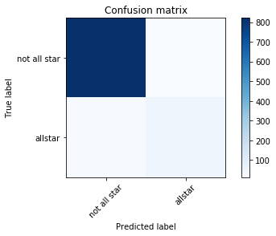

```
              precision    recall  f1-score   support

           0       0.98      0.98      0.98       834
           1       0.78      0.71      0.75        66

    accuracy                           0.96       900
   macro avg       0.88      0.85      0.86       900
weighted avg       0.96      0.96      0.96       900

Final accuracy: 0.9644444444444444
```

```python
# Compute confusion matrix
cm = confusion_matrix(y_test, pred2)
print(cm)

print('Ploting confusion matrix')
plt.figure()
plot_confusion_matrix(cm, ('not all star','allstar'))
plt.show()


print(classification_report(y_test, pred2))
print("Final accuracy: {}".format(score))
```

## Regularization

```python
names = list(df_final.columns.values)
print(names)
```

```
['PTS', 'AST', 'REB', 'HEIGHT', 'WEIGHT', 'SEASON_EXP', 'POSITION-Center', 'POSITION-Center-Forward', 'POSITION-Forward', 'POSITION-Forward-Center', 'POSITION-Forward-Guard', 'POSITION-Guard', 'POSITION-Guard-Forward', 'IS_ALLSTAR']
```

|  | coef | positive |
| --- | --- | --- |
| WEIGHT | -2.785079 | False |
| HEIGHT | -0.580967 | False |
| POSITION-Center-Forward | -0.447414 | False |
| AST | -0.279770 | False |
| POSITION-Guard-Forward | -0.160732 | False |
| POSITION-Forward-Guard | -0.029383 | False |
| POSITION-Forward-Center | 0.161109 | True |
| POSITION-Forward | 0.402423 | True |
| POSITION-Guard | 0.529910 | True |
| POSITION-Center | 0.555234 | True |
| SEASON_EXP | 3.264964 | True |
| PTS | 3.546472 | True |
| REB | 4.178914 | True |

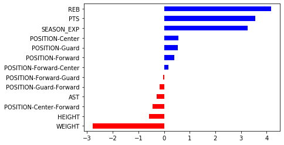

```python
# Create linear regression
regressor = LogisticRegression(penalty='elasticnet', solver='saga', l1_ratio=.1)

# Fit/train linear regression
regressor.fit(x_train,y_train)
# Predict
pred = regressor.predict(x_test)

regressor.coef_
names.remove("IS_ALLSTAR")

report_coef(names, regressor.coef_[0])
```

```python
df_final.drop('POSITION-Forward-Center',axis=1,inplace=True)
df_final.drop('POSITION-Forward-Guard',axis=1,inplace=True)
```

```python
df_final
```

|  | PTS | AST | REB | HEIGHT | WEIGHT | SEASON_EXP | POSITION-Center | POSITION-Center-Forward | POSITION-Forward | POSITION-Guard | POSITION-Guard-Forward | IS_ALLSTAR |
| --- | --- | --- | --- | --- | --- | --- | --- | --- | --- | --- | --- | --- |
| 0 | -0.641509 | -0.946429 | -0.711790 | 0.307692 | -0.057269 | -0.636364 | 0 | 0 | 1 | 0 | 0 | 0 |
| 1 | -0.433962 | -0.785714 | -0.301310 | 0.230769 | -0.101322 | -0.181818 | 1 | 0 | 0 | 0 | 0 | 0 |
| 2 | 0.547170 | -0.357143 | -0.021834 | 0.615385 | -0.189427 | 0.727273 | 1 | 0 | 0 | 0 | 0 | 1 |
| 3 | -0.081761 | -0.375000 | -0.834061 | -0.384615 | -0.744493 | -0.272727 | 0 | 0 | 0 | 1 | 0 | 0 |
| 4 | -0.509434 | -0.803571 | -0.711790 | 0.000000 | -0.101322 | -0.454545 | 0 | 0 | 0 | 0 | 0 | 0 |
| ... | ... | ... | ... | ... | ... | ... | ... | ... | ... | ... | ... | ... |
| 4495 | -0.622642 | -0.892857 | -0.659389 | 0.307692 | 0.171806 | -0.727273 | 1 | 0 | 0 | 0 | 0 | 0 |
| 4496 | -0.981132 | -0.982143 | -0.903930 | 0.538462 | -0.057269 | -1.000000 | 1 | 0 | 0 | 0 | 0 | 0 |
| 4497 | -0.861635 | -0.750000 | -0.921397 | -0.384615 | -0.674009 | -1.000000 | 0 | 0 | 0 | 1 | 0 | 0 |
| 4498 | -0.465409 | -0.803571 | -0.388646 | 0.461538 | -0.057269 | -0.636364 | 1 | 0 | 0 | 0 | 0 | 0 |
| 4499 | -0.691824 | -0.839286 | -0.790393 | -0.230769 | -0.453744 | -1.000000 | 0 | 0 | 0 | 1 | 0 | 0 |

4500 rows × 12 columns

```python
x_df = df_final.drop('IS_ALLSTAR',1)
x=x_df.values
y=df_final['IS_ALLSTAR'].values
```

### FNN Trials After Regularization

```python
x_train, x_test, y_train, y_test = train_test_split(x, y, test_size=0.2, random_state=42)
```

FNN Post Regularization Trial 1

```python
checkpointer = ModelCheckpoint(filepath="dnn/best_weights.hdf5", verbose=0, save_best_only=True)
for i in range(2):
    print(i)

    model = Sequential()
    model.add(Dense(10, input_dim=x.shape[1], activation='relu'))
    model.add(Dense(10))
    model.add(Dense(10))
    model.add(Dense(2, activation='softmax'))

    adam = optimizers.Adam(lr=0.01, beta_1=0.9, beta_2=0.999, epsilon=None, decay=0.0, amsgrad=False)
    sgd = optimizers.SGD(lr=1e-6)
    model.compile(loss='sparse_categorical_crossentropy', optimizer=adam)

    monitor = EarlyStopping(monitor='val_loss', min_delta=1e-3, patience=5, verbose=1, mode='auto')


    model.fit(x_train,y_train,validation_data=(x_test,y_test), batch_size= 32, callbacks=[monitor,checkpointer],verbose=2,epochs=500)


model.load_weights('dnn/best_weights.hdf5')


pred = model.predict(x_test)
pred = np.argmax(pred,axis=1)
#y_true = np.argmax(y_test,axis=1)

score = metrics.accuracy_score(y_test, pred)
print("Final accuracy: {}".format(score))
```

```
0
Train on 3600 samples, validate on 900 samples
3600/3600 - 4s - loss: 0.1548 - val_loss: 0.1079
3600/3600 - 0s - loss: 0.1248 - val_loss: 0.1064
3600/3600 - 0s - loss: 0.1196 - val_loss: 0.1140
3600/3600 - 0s - loss: 0.1133 - val_loss: 0.1136
3600/3600 - 0s - loss: 0.1099 - val_loss: 0.1103
3600/3600 - 0s - loss: 0.1113 - val_loss: 0.0977
3600/3600 - 0s - loss: 0.1113 - val_loss: 0.1019
3600/3600 - 0s - loss: 0.1090 - val_loss: 0.1009
3600/3600 - 0s - loss: 0.1059 - val_loss: 0.0938
3600/3600 - 0s - loss: 0.1063 - val_loss: 0.1012
3600/3600 - 0s - loss: 0.1074 - val_loss: 0.0953
3600/3600 - 0s - loss: 0.1045 - val_loss: 0.1000
3600/3600 - 0s - loss: 0.1045 - val_loss: 0.0988
3600/3600 - 0s - loss: 0.1040 - val_loss: 0.1001
Epoch 00014: early stopping
1
Train on 3600 samples, validate on 900 samples
3600/3600 - 2s - loss: 0.1630 - val_loss: 0.1030
3600/3600 - 0s - loss: 0.1210 - val_loss: 0.0999
3600/3600 - 0s - loss: 0.1134 - val_loss: 0.1055
3600/3600 - 0s - loss: 0.1137 - val_loss: 0.1046
3600/3600 - 0s - loss: 0.1084 - val_loss: 0.1001
3600/3600 - 0s - loss: 0.1102 - val_loss: 0.1020
3600/3600 - 0s - loss: 0.1053 - val_loss: 0.1000
Epoch 00007: early stopping
Final accuracy: 0.9633333333333334
```

FNN Post Regularization Trial 2

```python
checkpointer = ModelCheckpoint(filepath="dnn/best_weights.hdf5", verbose=0, save_best_only=True)
for i in range(2):
    print(i)

    model = Sequential()
    model.add(Dense(5, input_dim=x.shape[1], activation='sigmoid'))
    model.add(Dense(5))
    model.add(Dense(2, activation='softmax'))

    adam = optimizers.Adam(lr=0.01, beta_1=0.9, beta_2=0.999, epsilon=None, decay=0.0, amsgrad=False)
    sgd = optimizers.SGD(lr=1e-6)
    model.compile(loss='sparse_categorical_crossentropy', optimizer=adam)

    monitor = EarlyStopping(monitor='val_loss', min_delta=1e-3, patience=5, verbose=1, mode='auto')


    model.fit(x_train,y_train,validation_data=(x_test,y_test), batch_size= 32, callbacks=[monitor,checkpointer],verbose=2,epochs=500)


model.load_weights('dnn/best_weights.hdf5')


pred = model.predict(x_test)
pred = np.argmax(pred,axis=1)
#y_true = np.argmax(y_test,axis=1)

score = metrics.accuracy_score(y_test, pred)
print("Final accuracy: {}".format(score))
```

```
0
Train on 3600 samples, validate on 900 samples
3600/3600 - 2s - loss: 0.2484 - val_loss: 0.1399
3600/3600 - 0s - loss: 0.1370 - val_loss: 0.1303
3600/3600 - 0s - loss: 0.1319 - val_loss: 0.1128
3600/3600 - 0s - loss: 0.1283 - val_loss: 0.1213
3600/3600 - 0s - loss: 0.1276 - val_loss: 0.1121
3600/3600 - 0s - loss: 0.1281 - val_loss: 0.1113
3600/3600 - 0s - loss: 0.1257 - val_loss: 0.1134
3600/3600 - 0s - loss: 0.1246 - val_loss: 0.1099
3600/3600 - 0s - loss: 0.1250 - val_loss: 0.1115
3600/3600 - 0s - loss: 0.1221 - val_loss: 0.1179
3600/3600 - 0s - loss: 0.1248 - val_loss: 0.1091
3600/3600 - 0s - loss: 0.1227 - val_loss: 0.1123
3600/3600 - 0s - loss: 0.1222 - val_loss: 0.1102
Epoch 00013: early stopping
1
Train on 3600 samples, validate on 900 samples
3600/3600 - 1s - loss: 0.2652 - val_loss: 0.1819
3600/3600 - 0s - loss: 0.1535 - val_loss: 0.1134
3600/3600 - 0s - loss: 0.1340 - val_loss: 0.1212
3600/3600 - 0s - loss: 0.1303 - val_loss: 0.1110
3600/3600 - 0s - loss: 0.1273 - val_loss: 0.1118
3600/3600 - 0s - loss: 0.1247 - val_loss: 0.1203
3600/3600 - 1s - loss: 0.1291 - val_loss: 0.1090
3600/3600 - 0s - loss: 0.1265 - val_loss: 0.1093
3600/3600 - 0s - loss: 0.1241 - val_loss: 0.1098
3600/3600 - 0s - loss: 0.1245 - val_loss: 0.1094
3600/3600 - 0s - loss: 0.1238 - val_loss: 0.1094
3600/3600 - 0s - loss: 0.1227 - val_loss: 0.1097
Epoch 00012: early stopping
Final accuracy: 0.9611111111111111
```

FNN Post Regularization Trial 3

```python
checkpointer = ModelCheckpoint(filepath="dnn/best_weights.hdf5", verbose=0, save_best_only=True)
for i in range(2):
    print(i)

    model = Sequential()
    model.add(Dense(5, input_dim=x.shape[1], activation='tanh'))
    model.add(Dense(5))
    model.add(Dense(2, activation='softmax'))

    adam = optimizers.Adam(lr=0.01, beta_1=0.9, beta_2=0.999, epsilon=None, decay=0.0, amsgrad=False)
    sgd = optimizers.SGD(lr=1e-6)
    model.compile(loss='sparse_categorical_crossentropy', optimizer=sgd)

    monitor = EarlyStopping(monitor='val_loss', min_delta=1e-3, patience=5, verbose=1, mode='auto')


    model.fit(x_train,y_train,validation_data=(x_test,y_test), batch_size= 32, callbacks=[monitor,checkpointer],verbose=2,epochs=500)


model.load_weights('dnn/best_weights.hdf5')


pred = model.predict(x_test)
pred = np.argmax(pred,axis=1)
#y_true = np.argmax(y_test,axis=1)

score = metrics.accuracy_score(y_test, pred)
print("Final accuracy: {}".format(score))
```

```
0
Train on 3600 samples, validate on 900 samples
3600/3600 - 2s - loss: 0.8974 - val_loss: 0.8931
3600/3600 - 0s - loss: 0.8971 - val_loss: 0.8928
3600/3600 - 0s - loss: 0.8967 - val_loss: 0.8924
3600/3600 - 0s - loss: 0.8963 - val_loss: 0.8920
3600/3600 - 0s - loss: 0.8959 - val_loss: 0.8916
3600/3600 - 0s - loss: 0.8955 - val_loss: 0.8912
3600/3600 - 0s - loss: 0.8951 - val_loss: 0.8908
3600/3600 - 0s - loss: 0.8948 - val_loss: 0.8904
3600/3600 - 0s - loss: 0.8944 - val_loss: 0.8900
3600/3600 - 0s - loss: 0.8940 - val_loss: 0.8896
3600/3600 - 0s - loss: 0.8936 - val_loss: 0.8893
3600/3600 - 0s - loss: 0.8932 - val_loss: 0.8889
3600/3600 - 0s - loss: 0.8929 - val_loss: 0.8885
3600/3600 - 0s - loss: 0.8925 - val_loss: 0.8881
3600/3600 - 0s - loss: 0.8921 - val_loss: 0.8877
3600/3600 - 0s - loss: 0.8917 - val_loss: 0.8873
3600/3600 - 0s - loss: 0.8913 - val_loss: 0.8869
3600/3600 - 0s - loss: 0.8910 - val_loss: 0.8866
3600/3600 - 0s - loss: 0.8906 - val_loss: 0.8862
3600/3600 - 0s - loss: 0.8902 - val_loss: 0.8858
3600/3600 - 0s - loss: 0.8898 - val_loss: 0.8854
3600/3600 - 0s - loss: 0.8894 - val_loss: 0.8850
3600/3600 - 0s - loss: 0.8891 - val_loss: 0.8846
3600/3600 - 0s - loss: 0.8887 - val_loss: 0.8842
3600/3600 - 0s - loss: 0.8883 - val_loss: 0.8839
3600/3600 - 0s - loss: 0.8879 - val_loss: 0.8835
3600/3600 - 0s - loss: 0.8875 - val_loss: 0.8831
3600/3600 - 0s - loss: 0.8872 - val_loss: 0.8827
3600/3600 - 0s - loss: 0.8868 - val_loss: 0.8823
3600/3600 - 0s - loss: 0.8864 - val_loss: 0.8820
3600/3600 - 0s - loss: 0.8860 - val_loss: 0.8816
3600/3600 - 0s - loss: 0.8857 - val_loss: 0.8812
3600/3600 - 0s - loss: 0.8853 - val_loss: 0.8808
3600/3600 - 0s - loss: 0.8849 - val_loss: 0.8804
3600/3600 - 0s - loss: 0.8845 - val_loss: 0.8800
3600/3600 - 0s - loss: 0.8842 - val_loss: 0.8797
3600/3600 - 0s - loss: 0.8838 - val_loss: 0.8793
3600/3600 - 0s - loss: 0.8834 - val_loss: 0.8789
```

[output cut: 734 more lines]

```
3600/3600 - 0s - loss: 0.5382 - val_loss: 0.5331
3600/3600 - 0s - loss: 0.5381 - val_loss: 0.5329
3600/3600 - 0s - loss: 0.5379 - val_loss: 0.5327
3600/3600 - 0s - loss: 0.5377 - val_loss: 0.5325
3600/3600 - 0s - loss: 0.5375 - val_loss: 0.5323
3600/3600 - 0s - loss: 0.5373 - val_loss: 0.5321
3600/3600 - 0s - loss: 0.5371 - val_loss: 0.5319
3600/3600 - 0s - loss: 0.5369 - val_loss: 0.5317
3600/3600 - 0s - loss: 0.5367 - val_loss: 0.5315
3600/3600 - 0s - loss: 0.5365 - val_loss: 0.5313
3600/3600 - 0s - loss: 0.5363 - val_loss: 0.5311
3600/3600 - 0s - loss: 0.5361 - val_loss: 0.5309
3600/3600 - 0s - loss: 0.5359 - val_loss: 0.5307
Epoch 00283: early stopping
Final accuracy: 0.9011111111111111
```

FNN Post Regularization Trial 4

```python
checkpointer = ModelCheckpoint(filepath="dnn/best_weights.hdf5", verbose=0, save_best_only=True)
for i in range(2):
    print(i)

    model = Sequential()
    model.add(Dense(5, input_dim=x.shape[1], activation='relu'))
    model.add(Dense(5))
    model.add(Dense(2, activation='softmax'))

    adam = optimizers.Adam(lr=0.01, beta_1=0.9, beta_2=0.999, epsilon=None, decay=0.0, amsgrad=False)
    sgd = optimizers.SGD(lr=.001)
    model.compile(loss='sparse_categorical_crossentropy', optimizer=sgd)

    monitor = EarlyStopping(monitor='val_loss', min_delta=1e-3, patience=5, verbose=1, mode='auto')


    model.fit(x_train,y_train,validation_data=(x_test,y_test), batch_size= 32, callbacks=[monitor,checkpointer],verbose=2,epochs=500)


model.load_weights('dnn/best_weights.hdf5')


pred = model.predict(x_test)
pred = np.argmax(pred,axis=1)
#y_true = np.argmax(y_test,axis=1)

score = metrics.accuracy_score(y_test, pred)
print("Final accuracy: {}".format(score))
```

```
0
Train on 3600 samples, validate on 900 samples
3600/3600 - 2s - loss: 0.6121 - val_loss: 0.5596
3600/3600 - 0s - loss: 0.5210 - val_loss: 0.4756
3600/3600 - 0s - loss: 0.4502 - val_loss: 0.4119
3600/3600 - 0s - loss: 0.4023 - val_loss: 0.3710
3600/3600 - 0s - loss: 0.3716 - val_loss: 0.3441
3600/3600 - 0s - loss: 0.3513 - val_loss: 0.3257
3600/3600 - 0s - loss: 0.3372 - val_loss: 0.3126
3600/3600 - 0s - loss: 0.3271 - val_loss: 0.3030
3600/3600 - 0s - loss: 0.3196 - val_loss: 0.2956
3600/3600 - 0s - loss: 0.3137 - val_loss: 0.2898
3600/3600 - 0s - loss: 0.3090 - val_loss: 0.2850
3600/3600 - 0s - loss: 0.3050 - val_loss: 0.2809
3600/3600 - 0s - loss: 0.3016 - val_loss: 0.2774
3600/3600 - 0s - loss: 0.2985 - val_loss: 0.2742
3600/3600 - 0s - loss: 0.2958 - val_loss: 0.2715
3600/3600 - 0s - loss: 0.2933 - val_loss: 0.2690
3600/3600 - 0s - loss: 0.2910 - val_loss: 0.2667
3600/3600 - 0s - loss: 0.2889 - val_loss: 0.2645
3600/3600 - 0s - loss: 0.2869 - val_loss: 0.2625
3600/3600 - 0s - loss: 0.2849 - val_loss: 0.2606
3600/3600 - 0s - loss: 0.2831 - val_loss: 0.2588
3600/3600 - 0s - loss: 0.2814 - val_loss: 0.2571
3600/3600 - 0s - loss: 0.2797 - val_loss: 0.2554
3600/3600 - 0s - loss: 0.2781 - val_loss: 0.2538
3600/3600 - 0s - loss: 0.2765 - val_loss: 0.2523
3600/3600 - 0s - loss: 0.2749 - val_loss: 0.2508
3600/3600 - 0s - loss: 0.2734 - val_loss: 0.2493
3600/3600 - 0s - loss: 0.2720 - val_loss: 0.2479
3600/3600 - 0s - loss: 0.2705 - val_loss: 0.2466
3600/3600 - 0s - loss: 0.2691 - val_loss: 0.2452
3600/3600 - 0s - loss: 0.2677 - val_loss: 0.2439
3600/3600 - 0s - loss: 0.2663 - val_loss: 0.2426
3600/3600 - 0s - loss: 0.2649 - val_loss: 0.2414
3600/3600 - 0s - loss: 0.2636 - val_loss: 0.2401
3600/3600 - 0s - loss: 0.2623 - val_loss: 0.2389
3600/3600 - 0s - loss: 0.2610 - val_loss: 0.2377
3600/3600 - 0s - loss: 0.2597 - val_loss: 0.2365
3600/3600 - 0s - loss: 0.2584 - val_loss: 0.2353
```

[output cut: 304 more lines]

```
3600/3600 - 0s - loss: 0.1405 - val_loss: 0.1166
3600/3600 - 0s - loss: 0.1402 - val_loss: 0.1164
3600/3600 - 0s - loss: 0.1400 - val_loss: 0.1162
3600/3600 - 0s - loss: 0.1397 - val_loss: 0.1159
3600/3600 - 0s - loss: 0.1395 - val_loss: 0.1157
3600/3600 - 0s - loss: 0.1393 - val_loss: 0.1155
3600/3600 - 0s - loss: 0.1390 - val_loss: 0.1153
3600/3600 - 0s - loss: 0.1388 - val_loss: 0.1151
3600/3600 - 0s - loss: 0.1386 - val_loss: 0.1149
3600/3600 - 0s - loss: 0.1384 - val_loss: 0.1147
3600/3600 - 0s - loss: 0.1382 - val_loss: 0.1145
3600/3600 - 0s - loss: 0.1379 - val_loss: 0.1143
3600/3600 - 0s - loss: 0.1377 - val_loss: 0.1141
Epoch 00152: early stopping
Final accuracy: 0.9511111111111111
```

### Best Post Regularization FNN Model

FNN Post Regularization Trial 1

```python
model.summary()
```

[output not shown]

```
[[817  17]
 [ 16  50]]
Ploting confusion matrix
```

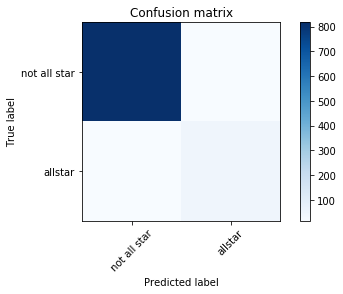

```
              precision    recall  f1-score   support

           0       0.98      0.98      0.98       834
           1       0.75      0.76      0.75        66

    accuracy                           0.96       900
   macro avg       0.86      0.87      0.87       900
weighted avg       0.96      0.96      0.96       900

Final accuracy: 0.9633333333333334
```

```python
cm = confusion_matrix(y_test, pred)
print(cm)

print('Ploting confusion matrix')
plt.figure()
plot_confusion_matrix(cm, ('not all star','allstar'))
plt.show()


print(classification_report(y_test, pred))
print("Final accuracy: {}".format(score))
```

### CNN Trials After Regularization

CNN Post Regularization Trial 1

```python
xx= x.reshape((4500,1,13,1))
```

```python
cnn = Sequential()
cnn.add(Conv2D(256, kernel_size=(1, 2), strides=(1, 1),
                 activation='relu',
                 input_shape=(1, 13, 1)))


cnn.add(MaxPooling2D(pool_size=(1,2)))

cnn.add(Conv2D(256, kernel_size=(1, 2), strides=(1, 1),
                 activation='relu'))
cnn.add(MaxPooling2D(pool_size=(1,2)))


cnn.add(Flatten())
cnn.add(Dense(1024, activation="sigmoid"))
cnn.add(Dropout(0.5))
cnn.add(Dense(2, activation="softmax"))

# define optimizer and objective, compile cnn

cnn.compile(loss="sparse_categorical_crossentropy", optimizer="adam")

x_train, x_test, y_train, y_test = train_test_split(xx, y, test_size=0.2, random_state=42)

import time

start_time = time.time()
checkpointer = ModelCheckpoint(filepath="dnn/best_weights.hdf5", verbose=0, save_best_only=True)
for i in range(5):
    print(i)

    monitor = EarlyStopping(monitor='val_loss', min_delta=1e-3, patience=5, verbose=1, mode='auto')
    cnn.fit(x_train[0:2000], y_train[0:2000],
              batch_size=64,
              epochs=10,
              verbose=2,
               callbacks=[monitor,checkpointer],
              validation_data=(x_test[0:300], y_test[0:300]))

pred2 = cnn.predict(x_test)
pred2 = np.argmax(pred2,axis=1)
#y_true = np.argmax(y_test,axis=1)

score = metrics.accuracy_score(y_test, pred2)
print("Final accuracy: {}".format(score))
```

```
0
Train on 2000 samples, validate on 300 samples
2000/2000 - 3s - loss: 0.3418 - val_loss: 0.1925
2000/2000 - 0s - loss: 0.1951 - val_loss: 0.1030
2000/2000 - 0s - loss: 0.1453 - val_loss: 0.0822
2000/2000 - 0s - loss: 0.1478 - val_loss: 0.0830
2000/2000 - 0s - loss: 0.1341 - val_loss: 0.0815
2000/2000 - 0s - loss: 0.1249 - val_loss: 0.0768
2000/2000 - 0s - loss: 0.1268 - val_loss: 0.0857
2000/2000 - 0s - loss: 0.1347 - val_loss: 0.0779
2000/2000 - 0s - loss: 0.1291 - val_loss: 0.0772
2000/2000 - 0s - loss: 0.1259 - val_loss: 0.0793
1
Train on 2000 samples, validate on 300 samples
2000/2000 - 0s - loss: 0.1235 - val_loss: 0.0809
2000/2000 - 0s - loss: 0.1241 - val_loss: 0.0716
2000/2000 - 0s - loss: 0.1216 - val_loss: 0.0763
2000/2000 - 0s - loss: 0.1238 - val_loss: 0.0870
2000/2000 - 0s - loss: 0.1345 - val_loss: 0.0769
2000/2000 - 0s - loss: 0.1260 - val_loss: 0.0788
2000/2000 - 0s - loss: 0.1237 - val_loss: 0.0727
Epoch 00007: early stopping
2
Train on 2000 samples, validate on 300 samples
2000/2000 - 0s - loss: 0.1148 - val_loss: 0.0691
2000/2000 - 0s - loss: 0.1196 - val_loss: 0.0724
2000/2000 - 0s - loss: 0.1218 - val_loss: 0.0720
2000/2000 - 0s - loss: 0.1177 - val_loss: 0.0690
2000/2000 - 0s - loss: 0.1111 - val_loss: 0.0774
2000/2000 - 0s - loss: 0.1191 - val_loss: 0.0769
Epoch 00006: early stopping
3
Train on 2000 samples, validate on 300 samples
2000/2000 - 0s - loss: 0.1139 - val_loss: 0.0715
2000/2000 - 0s - loss: 0.1142 - val_loss: 0.0675
2000/2000 - 0s - loss: 0.1082 - val_loss: 0.0734
2000/2000 - 0s - loss: 0.1163 - val_loss: 0.0674
2000/2000 - 0s - loss: 0.1124 - val_loss: 0.0841
2000/2000 - 0s - loss: 0.1107 - val_loss: 0.0689
2000/2000 - 0s - loss: 0.1084 - val_loss: 0.0719
Epoch 00007: early stopping
4
Train on 2000 samples, validate on 300 samples
2000/2000 - 0s - loss: 0.1094 - val_loss: 0.0739
2000/2000 - 0s - loss: 0.1104 - val_loss: 0.0725
2000/2000 - 0s - loss: 0.1095 - val_loss: 0.0715
2000/2000 - 0s - loss: 0.1093 - val_loss: 0.0733
2000/2000 - 0s - loss: 0.1112 - val_loss: 0.0816
2000/2000 - 0s - loss: 0.1062 - val_loss: 0.0718
2000/2000 - 0s - loss: 0.1148 - val_loss: 0.0727
Epoch 00007: early stopping
Final accuracy: 0.9633333333333334
```

CNN Post Regularization Trial 2

```python
cnn = Sequential()
cnn.add(Conv2D(256, kernel_size=(1, 2), strides=(1, 1),
                 activation='tanh',
                 input_shape=(1, 13, 1)))


cnn.add(MaxPooling2D(pool_size=(1,2)))

cnn.add(Conv2D(256, kernel_size=(1, 2), strides=(1, 1),
                 activation='tanh'))
cnn.add(MaxPooling2D(pool_size=(1,2)))


cnn.add(Flatten())
cnn.add(Dense(1024, activation="tanh"))
cnn.add(Dropout(0.5))
cnn.add(Dense(2, activation="softmax"))

# define optimizer and objective, compile cnn

cnn.compile(loss="sparse_categorical_crossentropy", optimizer="adam")

x_train, x_test, y_train, y_test = train_test_split(xx, y, test_size=0.2, random_state=42)

import time

start_time = time.time()
checkpointer = ModelCheckpoint(filepath="dnn/best_weights.hdf5", verbose=0, save_best_only=True)
for i in range(5):
    print(i)

    monitor = EarlyStopping(monitor='val_loss', min_delta=1e-3, patience=5, verbose=1, mode='auto')
    cnn.fit(x_train[0:2000], y_train[0:2000],
              batch_size=64,
              epochs=10,
              verbose=2,
               callbacks=[monitor,checkpointer],
              validation_data=(x_test[0:300], y_test[0:300]))

pred2 = cnn.predict(x_test)
pred2 = np.argmax(pred2,axis=1)
#y_true = np.argmax(y_test,axis=1)

score = metrics.accuracy_score(y_test, pred2)
print("Final accuracy: {}".format(score))
```

```
0
Train on 2000 samples, validate on 300 samples
2000/2000 - 3s - loss: 0.2136 - val_loss: 0.0966
2000/2000 - 0s - loss: 0.1369 - val_loss: 0.0983
2000/2000 - 0s - loss: 0.1363 - val_loss: 0.0902
2000/2000 - 0s - loss: 0.1214 - val_loss: 0.0856
2000/2000 - 0s - loss: 0.1313 - val_loss: 0.0867
2000/2000 - 0s - loss: 0.1213 - val_loss: 0.0835
2000/2000 - 0s - loss: 0.1216 - val_loss: 0.0901
2000/2000 - 0s - loss: 0.1245 - val_loss: 0.0880
2000/2000 - 0s - loss: 0.1186 - val_loss: 0.0827
2000/2000 - 0s - loss: 0.1186 - val_loss: 0.0807
1
Train on 2000 samples, validate on 300 samples
2000/2000 - 0s - loss: 0.1221 - val_loss: 0.0892
2000/2000 - 0s - loss: 0.1162 - val_loss: 0.0801
2000/2000 - 0s - loss: 0.1235 - val_loss: 0.0773
2000/2000 - 0s - loss: 0.1208 - val_loss: 0.0850
2000/2000 - 0s - loss: 0.1181 - val_loss: 0.0849
2000/2000 - 0s - loss: 0.1108 - val_loss: 0.0826
2000/2000 - 0s - loss: 0.1161 - val_loss: 0.0795
2000/2000 - 0s - loss: 0.1151 - val_loss: 0.0764
Epoch 00008: early stopping
2
Train on 2000 samples, validate on 300 samples
2000/2000 - 0s - loss: 0.1132 - val_loss: 0.0743
2000/2000 - 0s - loss: 0.1174 - val_loss: 0.0754
2000/2000 - 0s - loss: 0.1124 - val_loss: 0.0797
2000/2000 - 0s - loss: 0.1145 - val_loss: 0.0819
2000/2000 - 0s - loss: 0.1099 - val_loss: 0.0794
2000/2000 - 0s - loss: 0.1151 - val_loss: 0.0776
Epoch 00006: early stopping
3
Train on 2000 samples, validate on 300 samples
2000/2000 - 0s - loss: 0.1126 - val_loss: 0.0746
2000/2000 - 0s - loss: 0.1106 - val_loss: 0.0839
2000/2000 - 0s - loss: 0.1142 - val_loss: 0.0772
2000/2000 - 0s - loss: 0.1123 - val_loss: 0.0738
2000/2000 - 0s - loss: 0.1142 - val_loss: 0.0893
2000/2000 - 0s - loss: 0.1193 - val_loss: 0.0761
Epoch 00006: early stopping
4
Train on 2000 samples, validate on 300 samples
2000/2000 - 0s - loss: 0.1119 - val_loss: 0.0771
2000/2000 - 0s - loss: 0.1142 - val_loss: 0.0756
2000/2000 - 0s - loss: 0.1080 - val_loss: 0.0776
2000/2000 - 0s - loss: 0.1078 - val_loss: 0.0724
2000/2000 - 0s - loss: 0.1062 - val_loss: 0.0844
2000/2000 - 0s - loss: 0.1070 - val_loss: 0.0759
2000/2000 - 0s - loss: 0.1113 - val_loss: 0.0689
2000/2000 - 0s - loss: 0.1062 - val_loss: 0.0739
2000/2000 - 0s - loss: 0.1082 - val_loss: 0.0692
2000/2000 - 0s - loss: 0.1166 - val_loss: 0.0776
Final accuracy: 0.9644444444444444
```

CNN Post Regularization Trial 3

```python
cnn = Sequential()
cnn.add(Conv2D(256, kernel_size=(1, 2), strides=(1, 1),
                 activation='relu',
                 input_shape=(1, 13, 1)))


cnn.add(MaxPooling2D(pool_size=(1,2)))

cnn.add(Conv2D(256, kernel_size=(1, 2), strides=(1, 1),
                 activation='relu'))
cnn.add(MaxPooling2D(pool_size=(1,2)))


cnn.add(Flatten())
cnn.add(Dense(1024, activation="sigmoid"))
cnn.add(Dropout(0.5))
cnn.add(Dense(2, activation="softmax"))

# define optimizer and objective, compile cnn

cnn.compile(loss="sparse_categorical_crossentropy", optimizer="adam")

x_train, x_test, y_train, y_test = train_test_split(xx, y, test_size=0.2, random_state=42)

import time

start_time = time.time()
checkpointer = ModelCheckpoint(filepath="dnn/best_weights.hdf5", verbose=0, save_best_only=True)
for i in range(5):
    print(i)

    monitor = EarlyStopping(monitor='val_loss', min_delta=1e-3, patience=5, verbose=1, mode='auto')
    cnn.fit(x_train[0:2000], y_train[0:2000],
              batch_size=64,
              epochs=10,
              verbose=2,
               callbacks=[monitor,checkpointer],
              validation_data=(x_test[0:300], y_test[0:300]))

pred2 = cnn.predict(x_test)
pred2 = np.argmax(pred2,axis=1)
#y_true = np.argmax(y_test,axis=1)

score = metrics.accuracy_score(y_test, pred2)
print("Final accuracy: {}".format(score))
```

```
0
Train on 2000 samples, validate on 300 samples
2000/2000 - 3s - loss: 0.3761 - val_loss: 0.2240
2000/2000 - 1s - loss: 0.2151 - val_loss: 0.1117
2000/2000 - 0s - loss: 0.1577 - val_loss: 0.0854
2000/2000 - 0s - loss: 0.1329 - val_loss: 0.0850
2000/2000 - 0s - loss: 0.1353 - val_loss: 0.0905
2000/2000 - 0s - loss: 0.1376 - val_loss: 0.0809
2000/2000 - 0s - loss: 0.1379 - val_loss: 0.0785
2000/2000 - 0s - loss: 0.1271 - val_loss: 0.0795
2000/2000 - 0s - loss: 0.1238 - val_loss: 0.0752
2000/2000 - 0s - loss: 0.1341 - val_loss: 0.0776
1
Train on 2000 samples, validate on 300 samples
2000/2000 - 0s - loss: 0.1240 - val_loss: 0.0782
2000/2000 - 0s - loss: 0.1295 - val_loss: 0.0751
2000/2000 - 0s - loss: 0.1215 - val_loss: 0.0732
2000/2000 - 0s - loss: 0.1338 - val_loss: 0.0728
2000/2000 - 0s - loss: 0.1179 - val_loss: 0.0715
2000/2000 - 0s - loss: 0.1239 - val_loss: 0.0719
2000/2000 - 0s - loss: 0.1239 - val_loss: 0.0793
2000/2000 - 0s - loss: 0.1279 - val_loss: 0.0710
2000/2000 - 0s - loss: 0.1164 - val_loss: 0.0685
2000/2000 - 0s - loss: 0.1244 - val_loss: 0.0675
2
Train on 2000 samples, validate on 300 samples
2000/2000 - 0s - loss: 0.1217 - val_loss: 0.0748
2000/2000 - 0s - loss: 0.1233 - val_loss: 0.0746
2000/2000 - 0s - loss: 0.1143 - val_loss: 0.0734
2000/2000 - 0s - loss: 0.1130 - val_loss: 0.0813
2000/2000 - 0s - loss: 0.1302 - val_loss: 0.0721
2000/2000 - 0s - loss: 0.1089 - val_loss: 0.0694
2000/2000 - 0s - loss: 0.1143 - val_loss: 0.0786
2000/2000 - 0s - loss: 0.1137 - val_loss: 0.0883
2000/2000 - 0s - loss: 0.1149 - val_loss: 0.0719
2000/2000 - 0s - loss: 0.1157 - val_loss: 0.0675
3
Train on 2000 samples, validate on 300 samples
2000/2000 - 0s - loss: 0.1098 - val_loss: 0.0726
2000/2000 - 0s - loss: 0.1098 - val_loss: 0.0738
2000/2000 - 0s - loss: 0.1080 - val_loss: 0.0794
2000/2000 - 0s - loss: 0.1166 - val_loss: 0.0733
2000/2000 - 0s - loss: 0.1065 - val_loss: 0.0718
2000/2000 - 0s - loss: 0.1097 - val_loss: 0.0695
2000/2000 - 0s - loss: 0.1077 - val_loss: 0.0715
2000/2000 - 0s - loss: 0.1060 - val_loss: 0.0697
2000/2000 - 0s - loss: 0.1047 - val_loss: 0.0720
2000/2000 - 0s - loss: 0.1061 - val_loss: 0.0664
4
Train on 2000 samples, validate on 300 samples
2000/2000 - 0s - loss: 0.0994 - val_loss: 0.0754
2000/2000 - 0s - loss: 0.1143 - val_loss: 0.0684
2000/2000 - 0s - loss: 0.1142 - val_loss: 0.0839
2000/2000 - 0s - loss: 0.1088 - val_loss: 0.0748
2000/2000 - 0s - loss: 0.1098 - val_loss: 0.0735
2000/2000 - 0s - loss: 0.0996 - val_loss: 0.0721
2000/2000 - 0s - loss: 0.1030 - val_loss: 0.0741
Epoch 00007: early stopping
Final accuracy: 0.9577777777777777
```

### Best CNN Model Post Regularization

Trial 2 Post Regularization CNN Model

```python
cnn.summary()
```

```
Model: "sequential_47"
_________________________________________________________________
Layer (type)                 Output Shape              Param #
=================================================================
conv2d_30 (Conv2D)           (None, 1, 12, 256)        768
_________________________________________________________________
max_pooling2d_27 (MaxPooling (None, 1, 6, 256)         0
_________________________________________________________________
conv2d_31 (Conv2D)           (None, 1, 5, 256)         131328
_________________________________________________________________
max_pooling2d_28 (MaxPooling (None, 1, 2, 256)         0
_________________________________________________________________
flatten_11 (Flatten)         (None, 512)               0
_________________________________________________________________
dense_117 (Dense)            (None, 1024)              525312
_________________________________________________________________
dropout_11 (Dropout)         (None, 1024)              0
_________________________________________________________________
dense_118 (Dense)            (None, 2)                 2050
=================================================================
Total params: 659,458
Trainable params: 659,458
Non-trainable params: 0
_________________________________________________________________
```

```
[[820  14]
 [ 18  48]]
Ploting confusion matrix
```

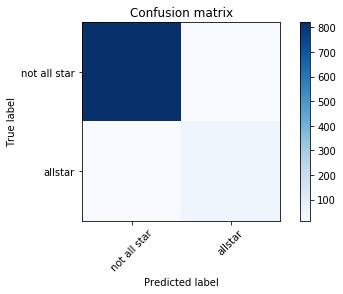

```
              precision    recall  f1-score   support

           0       0.98      0.98      0.98       834
           1       0.77      0.73      0.75        66

    accuracy                           0.96       900
   macro avg       0.88      0.86      0.87       900
weighted avg       0.96      0.96      0.96       900

Final accuracy: 0.9644444444444444
```

```python
cm = confusion_matrix(y_test, pred2)
print(cm)

print('Ploting confusion matrix')
plt.figure()
plot_confusion_matrix(cm, ('not all star','allstar'))
plt.show()


print(classification_report(y_test, pred2))
print("Final accuracy: {}".format(score))
```